# Pràctica 2 - Neteja i anàlisis de les dades

David Navarro, Antoni Llussà

22/5/2020

```r
#carrega de llibreries per mostrar taules
library(knitr)
library(kableExtra)
library("ggplot2")
library(nortest)
library(corrplot)
```

# Pràctica 2 - Neteja i anàlisis de les dades - Pokemon Dataset

## 0. Carrega del dataset.

```r
#pokedex <- read.csv("/Users/davidnavarrobrugal/Downloads/pokedex_(Update_05.20).csv",header=TRUE, stringsAsFactors = TRUE,encoding = "UTF-8")
pokedex <- read.csv("dataset/pokedex_(Update_05.20).csv",header=TRUE, stringsAsFactors = TRUE,encoding = "UTF-8")
```

Visualitzem les 5 primeres linies del csv.

```r
head(pokedex)
```

|  | X | pokedex_number | name | german_name | japanese_name | generation | status | species | type_number | type_1 | type_2 | height_m | weight_kg | abilities_number | ability_1 | ability_2 | ability_hidden | total_points | hp | attack | defense | sp_attack | sp_defense | speed | catch_rate | base_friendship | base_experience | growth_rate | egg_type_number | … |
| --- | --- | --- | --- | --- | --- | --- | --- | --- | --- | --- | --- | --- | --- | --- | --- | --- | --- | --- | --- | --- | --- | --- | --- | --- | --- | --- | --- | --- | --- | --- |
| 1 | 0 | 1 | Bulbasaur | Bisasam | (Fushigidane) | 1 | Normal | Seed Pokémon | 2 | Grass | Poison | 0.7 | 6.9 | 2 | Overgrow |  | Chlorophyll | 318 | 45 | 49 | 49 | 65 | 65 | 45 | 45 | 70 | 64 | Medium Slow | 2 | … |
| 2 | 1 | 2 | Ivysaur | Bisaknosp | (Fushigisou) | 1 | Normal | Seed Pokémon | 2 | Grass | Poison | 1.0 | 13.0 | 2 | Overgrow |  | Chlorophyll | 405 | 60 | 62 | 63 | 80 | 80 | 60 | 45 | 70 | 142 | Medium Slow | 2 | … |
| 3 | 2 | 3 | Venusaur | Bisaflor | (Fushigibana) | 1 | Normal | Seed Pokémon | 2 | Grass | Poison | 2.0 | 100.0 | 2 | Overgrow |  | Chlorophyll | 525 | 80 | 82 | 83 | 100 | 100 | 80 | 45 | 70 | 236 | Medium Slow | 2 | … |
| 4 | 3 | 3 | Mega Venusaur | Bisaflor | (Fushigibana) | 1 | Normal | Seed Pokémon | 2 | Grass | Poison | 2.4 | 155.5 | 1 | Thick Fat |  |  | 625 | 80 | 100 | 123 | 122 | 120 | 80 | 45 | 70 | 281 | Medium Slow | 2 | … |
| 5 | 4 | 4 | Charmander | Glumanda | (Hitokage) | 1 | Normal | Lizard Pokémon | 1 | Fire |  | 0.6 | 8.5 | 2 | Blaze |  | Solar Power | 309 | 39 | 52 | 43 | 60 | 50 | 65 | 45 | 70 | 62 | Medium Slow | 2 | … |
| 6 | 5 | 5 | Charmeleon | Glutexo | (Lizardo) | 1 | Normal | Flame Pokémon | 1 | Fire |  | 1.1 | 19.0 | 2 | Blaze |  | Solar Power | 405 | 58 | 64 | 58 | 80 | 65 | 80 | 45 | 70 | 142 | Medium Slow | 2 | … |

Per inspeccionar el fitxer, utilitzarem la instrucció *str*. On veurem el nombre d’observacions, el nombre de variables, el nom de les variables i de quin tipus són.

```r
str(pokedex)
```

```
## 'data.frame':    1028 obs. of  51 variables:
##  $ X               : int  0 1 2 3 4 5 6 7 8 9 ...
##  $ pokedex_number  : int  1 2 3 3 4 5 6 6 6 7 ...
##  $ name            : Factor w/ 1028 levels "Abomasnow","Abra",..: 105 426 958 582 132 133 130 548 549 859 ...
##  $ german_name     : Factor w/ 808 levels "","Aalabyss",..: 54 53 52 52 221 223 222 222 222 607 ...
##  $ japanese_name   : Factor w/ 808 levels "","アイアント (Aiant)",..: 566 565 567 567 525 770 771 771 771 317 ...
##  $ generation      : int  1 1 1 1 1 1 1 1 1 1 ...
##  $ status          : Factor w/ 4 levels "Legendary","Mythical",..: 3 3 3 3 3 3 3 3 3 3 ...
##  $ species         : Factor w/ 641 levels "Abundance Pokémon",..: 487 487 487 487 328 208 208 208 208 577 ...
##  $ type_number     : int  2 2 2 2 1 1 2 2 2 1 ...
##  $ type_1          : Factor w/ 18 levels "Bug","Dark","Dragon",..: 10 10 10 10 7 7 7 7 7 18 ...
##  $ type_2          : Factor w/ 19 levels "","Bug","Dark",..: 15 15 15 15 1 1 9 4 9 1 ...
##  $ height_m        : num  0.7 1 2 2.4 0.6 1.1 1.7 1.7 1.7 0.5 ...
##  $ weight_kg       : num  6.9 13 100 155.5 8.5 ...
##  $ abilities_number: int  2 2 2 1 2 2 2 1 1 2 ...
```

[output cut: 37 more lines]

Utilitzarem la instrucció *summary* per veure les freqüències, min, max, mitjan, mediana, quartils i valors absents.

```r
summary(pokedex)
```

```
##        X          pokedex_number                      name
##  Min.   :   0.0   Min.   :  1.0   Abomasnow             :   1
##  1st Qu.: 256.8   1st Qu.:213.8   Abra                  :   1
##  Median : 513.5   Median :433.5   Absol                 :   1
##  Mean   : 513.5   Mean   :437.7   Accelgor              :   1
##  3rd Qu.: 770.2   3rd Qu.:663.2   Aegislash Blade Forme :   1
##  Max.   :1027.0   Max.   :890.0   Aegislash Shield Forme:   1
##                                   (Other)               :1022
##      german_name                                               japanese_name
##            : 90                                                       : 90
##  Rotom     :  6   ロトム (Rotom)                    :  6
##  Choreogel :  4   オドリドリ (Odoridori):  4
##  Deoxys    :  4   デオキシス (Deoxys)   :  4
##  Flampivian:  4   ネクロズマ (Necrozma) :  4
##  Formeo    :  4   バケッチャ (Bakeccha) :  4
##  (Other)   :916   (Other)                                             :916
##    generation              status               species     type_number
##  Min.   :1.000   Legendary    : 39   Mouse Pokémon  : 12   Min.   :1.000
##  1st Qu.:2.000   Mythical     : 29   Dragon Pokémon :  9   1st Qu.:1.000
##  Median :4.000   Normal       :915   Fox Pokémon    :  9   Median :2.000
##  Mean   :4.034   Sub Legendary: 45   Pumpkin Pokémon:  8   Mean   :1.527
##  3rd Qu.:6.000                       Flame Pokémon  :  7   3rd Qu.:2.000
##  Max.   :8.000                       Bagworm Pokémon:  6   Max.   :2.000
##                                      (Other)        :977
##      type_1        type_2       height_m         weight_kg
##  Water  :134          :486   Min.   :  0.100   Min.   :  0.10
##  Normal :115   Flying :109   1st Qu.:  0.600   1st Qu.:  8.80
##  Grass  : 91   Fairy  : 41   Median :  1.000   Median : 28.50
##  Bug    : 81   Ground : 39   Mean   :  1.368   Mean   : 69.75
##  Psychic: 76   Poison : 38   3rd Qu.:  1.500   3rd Qu.: 69.10
##  Fire   : 65   Psychic: 38   Max.   :100.000   Max.   :999.90
##  (Other):466   (Other):277                     NA's   :1
##  abilities_number       ability_1         ability_2       ability_hidden
##  Min.   :0.000    Levitate   : 41              :515              :218
##  1st Qu.:2.000    Swift Swim : 30   Frisk      : 17   Telepathy  : 21
##  Median :2.000    Keen Eye   : 28   Sturdy     : 14   Sheer Force: 18
##  Mean   :2.284    Chlorophyll: 25   Shell Armor: 13   Overcoat   : 17
##  3rd Qu.:3.000    Pressure   : 25   Early Bird : 10   Unnerve    : 17
##  Max.   :3.000    Blaze      : 24   Gluttony   : 10   Regenerator: 15
##                   (Other)    :855   (Other)    :449   (Other)    :722
```

[output cut: 57 more lines]

```
##  Min.   :0.25   Min.   :0.000   Min.   :0.0000   Min.   :0.250
##  1st Qu.:1.00   1st Qu.:1.000   1st Qu.:1.0000   1st Qu.:1.000
##  Median :1.00   Median :1.000   Median :1.0000   Median :1.000
##  Mean   :1.24   Mean   :1.011   Mean   :0.9757   Mean   :1.066
##  3rd Qu.:2.00   3rd Qu.:1.000   3rd Qu.:1.0000   3rd Qu.:1.000
##  Max.   :4.00   Max.   :4.000   Max.   :2.0000   Max.   :4.000
##
##  against_steel    against_fairy
##  Min.   :0.0000   Min.   :0.000
##  1st Qu.:0.5000   1st Qu.:1.000
##  Median :1.0000   Median :1.000
##  Mean   :0.9803   Mean   :1.085
##  3rd Qu.:1.0000   3rd Qu.:1.000
##  Max.   :4.0000   Max.   :4.000
##
```

## 1. Descripció del dataset. Perquè és important i quina pregunta/problema pretén respondre?

El dataset escollit, és una base de dades del joc de Pokemon. El dataset, es pot descarregar a: https://www.kaggle.com/mariotormo/complete-pokemon-dataset-updated-090420, té la Llicència CC BY-SA 4.0, per tant la podem usar per realitzar en aquesta pràctica.

S’ha escollit aquest dataset perquè els dos membres del grup, tenim fills, i estan aficionats en aquest món. Aquest dataset ens ajudarà a saber quines tipologies de Pokemon hi ha, quines característiques tenen, quins són els Pokemons més forts, etc. La nostra experiència amb el joc, és nul·la, per tant haurem d’analitzar profundament el dataset i entendre que és cada una de les variables.

El dataset escollit, té dos arxius .csv, aquests dos arxius, estan actualitzats en dates diferents. Els hem analitzat i tots contenen la mateixa informació, però estructurada diferent per mostrar si són: Normal, Legendary, Mythical, Sub Legendary.

Utilitzarem l’arxiu pokedex_(Update_05.20).csv, conté 1028 observacions i 51 variables. La variable X, no la utilitzarem ja que no ens aporta informació, és un identificador de fila.

Les dades es poden agrupar en:

1. Informació de la Pokedex:
- *Pokedex_number:* Identificador del Pokémon dins de la Pokedex nacional
- *name:* Nom del Pokémon amb anglès.
- *german_name:* Nom del Pokémon amb alemany.
- *japanese_name:* Nom del Pokémon amb japonès.
- *generation:* Número de generació en que s’ha vist per primera vegada.
- *status:* Indica si el Pokémon és: normal, sub legendary, legendary or mythical
- *species:* Categoria del Pokémon.
- *type_number:* Nombre de tipus que té el Pokémon.
- *type_1:* El tipus primari del Pokémon.
- *type_2:* El tipus secundari del Pokémon.
- *height_m:* Alçada del Pokémon en metres.
- *weight_kg:* Pes del Pokémon en kg.
- *abilities_number:* Nombre d’habilitats del Pokémon.
- *ability_?:* Nom de l’habilitat.
- *ability_hidden:* Si té habilitat oculta, Nom de l’habilitat del Pokémon.
2. Informació d’estadistiques bàsiques:
- *total_points:* Nombre total de punts de base.
- *hp:* L’HP de base del Pokémon.
- *attack:* L’atac de base del Pokémon.
- *defense:* La defensa base del Pokémon.
- *sp_attack:* Atac especial de base del Pokémon.
- *sp_defense:* Defensa especial de base del Pokémon.
- *speed:* La velocitat base del Pokémon.
3. Informació d’entrenament:
- *catch_rate:* Taxa de captura del Pokémon.
- *base_friendship:* L’amistat base del Pokémon.
- *base_experience:* L’experiència de base d’un Pokémon salvatge quan és capturat.
- *growth_rate:* La taxa de creixement del Pokémon.
4. Informació de criança:
- *egg_type_number:* Nombre de grups on pot ser eclosionat.
- *egg_type_?:* Noms dels grups d’ou on es pot eclosionar un Pokemon.
- *percentage_male:* El percentatge de les espècies que són mascles. En blanc si el Pokemon no té gènere.
- *egg_cycles:* El nombre de cicles (255-257 passos) necessaris per eclosionar un ou del Pokémon.
5. Informació de tipus de defensa:
- *against_?:* Divuit funcions que informen la quantitat de danys causats contra un atac d’un tipus particular.

## 2. Integració i selecció de les dades d’interès a analitzar.

En aquest cas el dataset escollit, no es pot realitzar cap integració amb altres datasets, no n’hem trobat cap que pogués aportar més valor.

Per saber les dades d’interès a analitzar realitzarem un anàlisis visual per veure les variables de tipus factor i numèriques que ens criden l’atenció, per poder llavors decidir quin es l’estudi que es realitzarà:

#### Anàlisi descriptiva visual

#### Anàlisi de variables de tipus factor

##### Anàlisi de la variables generation

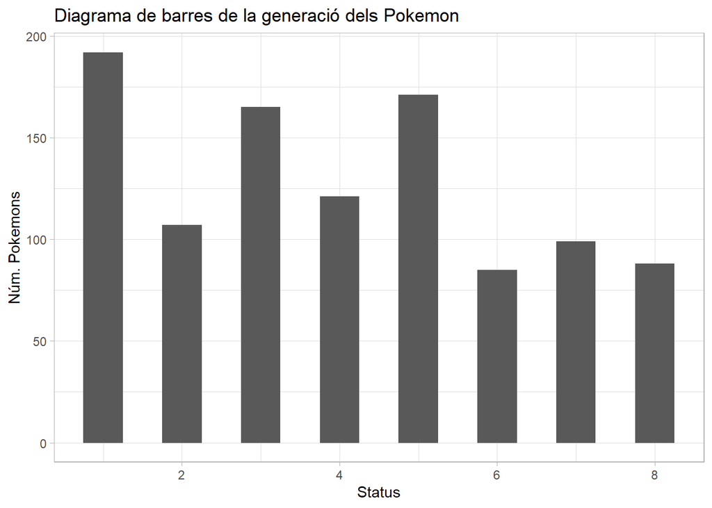

```r
gg <- ggplot(pokedex,  aes(x = generation, fill = generation)) +
      geom_bar(width=0.5) +   # bar chart
      theme_light() +   # theme
      labs(x = "Status",   # this labels the x axis
       y = "Núm. Pokemons",   # this labels the y axis
       title = "Diagrama de barres de la generació dels Pokemon") # title of the plot

gg
```

Es pot observar que a la primera generació és la que van aparèixer més Pokemons, llavors la cinquena i la tercera.

##### Anàlisi de la variables status

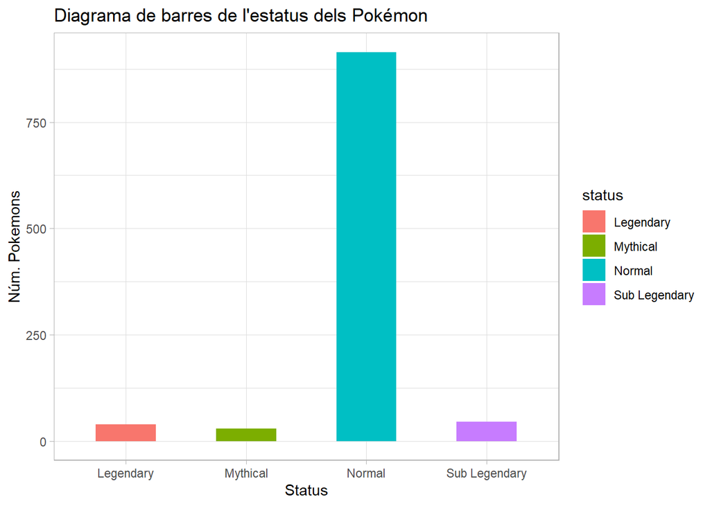

```r
gg <- ggplot(pokedex,  aes(x = status, fill = status)) +
      geom_bar(width=0.5) +   # bar chart
      theme_light() +   # theme
      labs(x = "Status",   # this labels the x axis
       y = "Núm. Pokemons",   # this labels the y axis
       title = "Diagrama de barres de l'estatus dels Pokémon") # title of the plot

gg
```

Es pot observar que la majoria dels Pokemons són normals, llavors de la classe Sub Legendary, Legendary i Mythical.

##### Anàlisi de la variable type_1 (tipus principal)

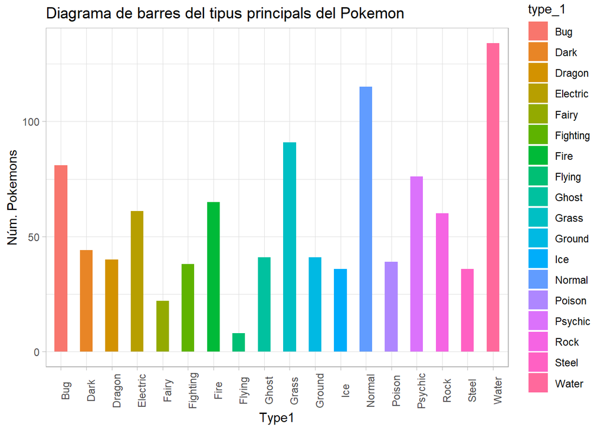

```r
gg <- ggplot(pokedex,  aes(x = type_1, fill = type_1)) +
      geom_bar(width=0.5) +   # bar chart
      theme_light() +   # theme
      labs(x = "Type1",   # this labels the x axis
       y = "Núm. Pokemons",   # this labels the y axis
       title = "Diagrama de barres del tipus principals del Pokemon") # title of the plot

gg+ theme(axis.text.x = element_text(angle = 90))
```

Es pot observar que la majoria són de tipus water, normal, grass, bug i psychic.

##### Anàlisi de la variable type_2 (tipus secundari)

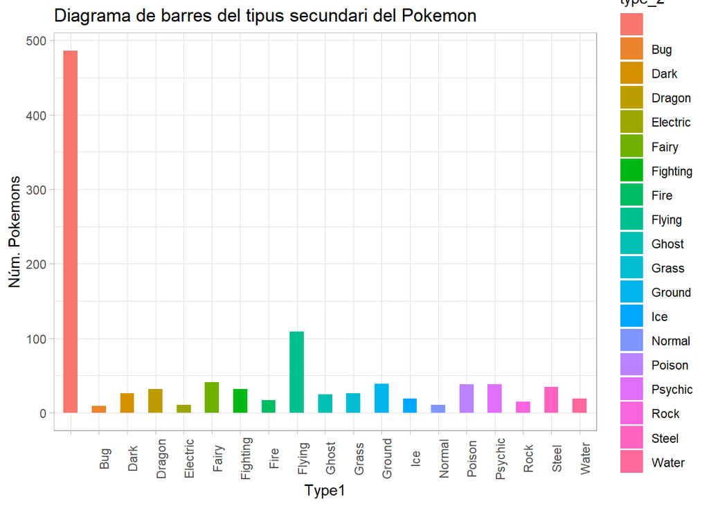

```r
gg <- ggplot(pokedex,  aes(x = type_2, fill = type_2)) +
      geom_bar(width=0.5) +   # bar chart
      theme_light() +   # theme
      labs(x = "Type1",   # this labels the x axis
       y = "Núm. Pokemons",   # this labels the y axis
       title = "Diagrama de barres del tipus secundari del Pokemon") # title of the plot

gg+ theme(axis.text.x = element_text(angle = 90))
```

Es pot observar que la majoria no tenen tipus secundari, i si en tenen la majoria són de flying.

##### Anàlisi dels tipus de Pokemons llegendaris

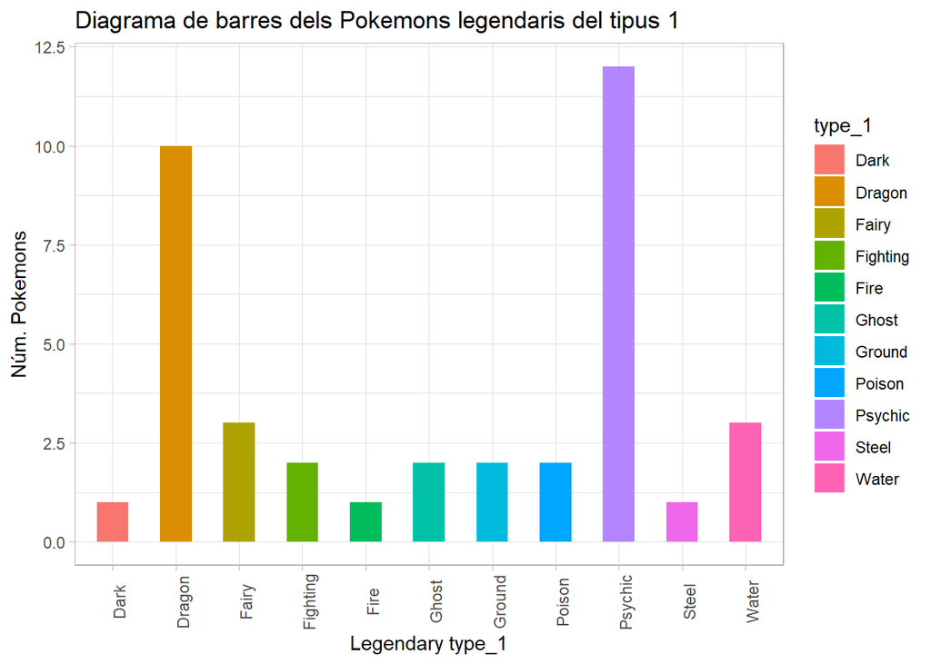

```r
pokedex %>%
  dplyr::filter(status == "Legendary") %>%
  ggplot(aes(x = type_1, fill = type_1)) +
      geom_bar(width=0.5) +   # bar chart
      theme_light() +   # theme
      labs(x = "Legendary type_1",   # this labels the x axis
      y = "Núm. Pokemons",   # this labels the y axis
      title = "Diagrama de barres dels Pokemons legendaris del tipus 1")+ # title of the plot
      theme(axis.text.x = element_text(angle = 90))
```

Es pot observar que la majoria de Pokemons llegendaris són de tipus Psychic i Dragon.

##### Anàlisi de la variable growth_rate (taxa de creixement)

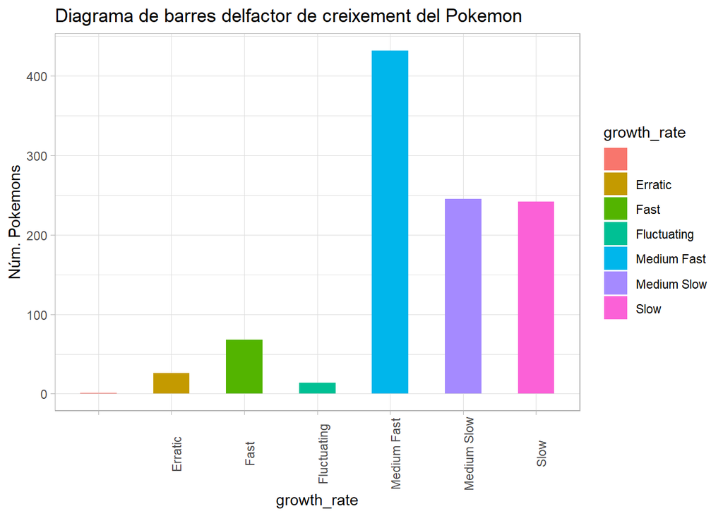

```r
gg <- ggplot(pokedex,  aes(x = growth_rate, fill = growth_rate)) +
      geom_bar(width=0.5) +   # bar chart
      theme_light() +   # theme
      labs(x = "growth_rate",   # this labels the x axis
       y = "Núm. Pokemons",   # this labels the y axis
       title = "Diagrama de barres delfactor de creixement del Pokemon") # title of the plot

gg+ theme(axis.text.x = element_text(angle = 90))
```

Es pot observar que la majoria creixen: Mediu Fast, Medium Slow i Slow.

##### Anàlisi de la variable egg_type_1 (Grups d’ous primer)

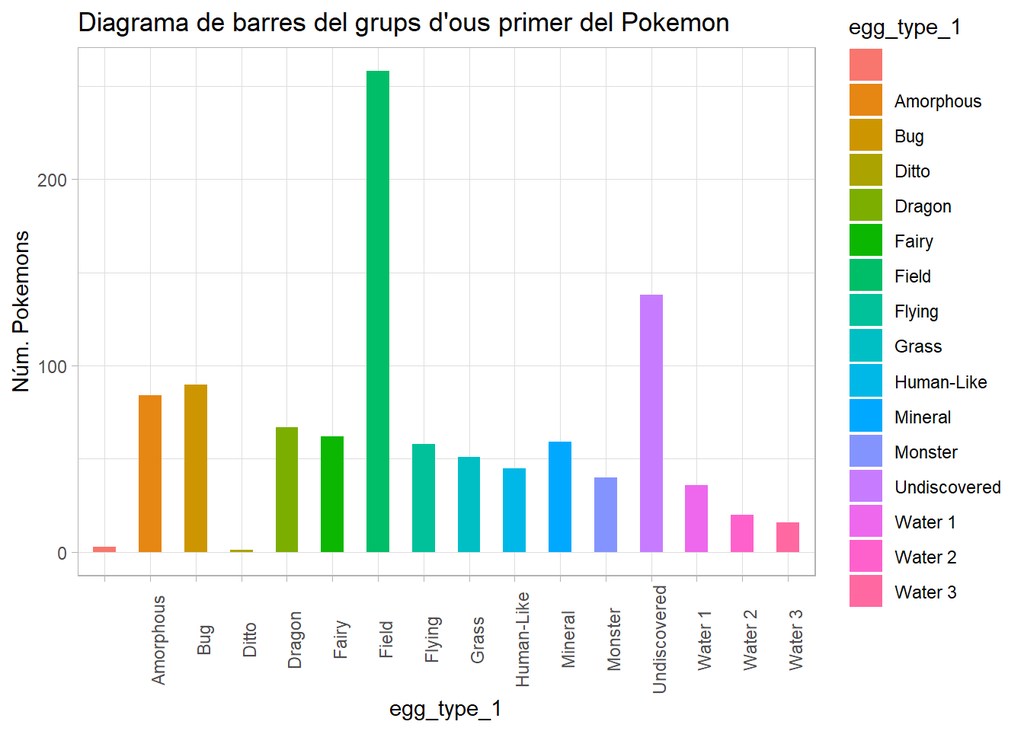

```r
gg <- ggplot(pokedex,  aes(x =  egg_type_1 , fill =  egg_type_1 )) +
      geom_bar(width=0.5) +   # bar chart
      theme_light() +   # theme
      labs(x = "egg_type_1",   # this labels the x axis
       y = "Núm. Pokemons",   # this labels the y axis
       title = "Diagrama de barres del grups d'ous primer del Pokemon") # title of the plot

gg+ theme(axis.text.x = element_text(angle = 90))
```

La majoria del tipus 1 eclosionen de tipus Field, Undiscovered, bug i Amorphous.

##### Anàlisi de la variable egg_type_2 (Grups d’ous segon)

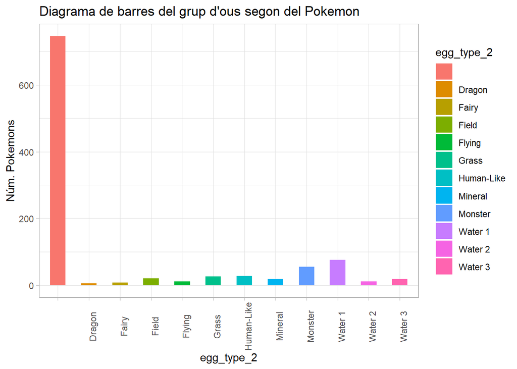

```r
gg <- ggplot(pokedex,  aes(x =  egg_type_2 , fill =  egg_type_2 )) +
      geom_bar(width=0.5) +   # bar chart
      theme_light() +   # theme
      labs(x = "egg_type_2",   # this labels the x axis
       y = "Núm. Pokemons",   # this labels the y axis
       title = "Diagrama de barres del grup d'ous segon del Pokemon") # title of the plot

gg+ theme(axis.text.x = element_text(angle = 90))
```

La majoria del tipus 2 no tenen tipus, llavors són de tipus Water1 i Monster.

#### Anàlisi de variables de tipus numèric informació de la pokedex

##### Anàlisis de la variable height_m

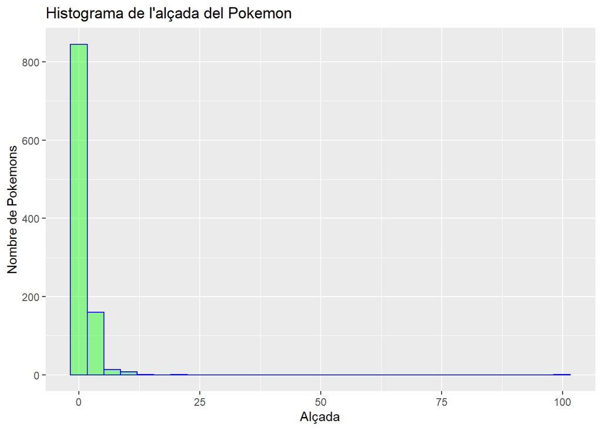

```r
gg <- ggplot(data=pokedex, aes(height_m)) +
      geom_histogram( col="blue", fill="green", alpha = .4) +
      labs(title="Histograma de l'alçada del Pokemon") + labs(x="Alçada", y="Nombre de Pokemons")
gg
```

Es pot observar que la majoria de pokemons són d’estatura baixa de 0 a 1 metre.

##### Anàlisis de la variable weight_kg

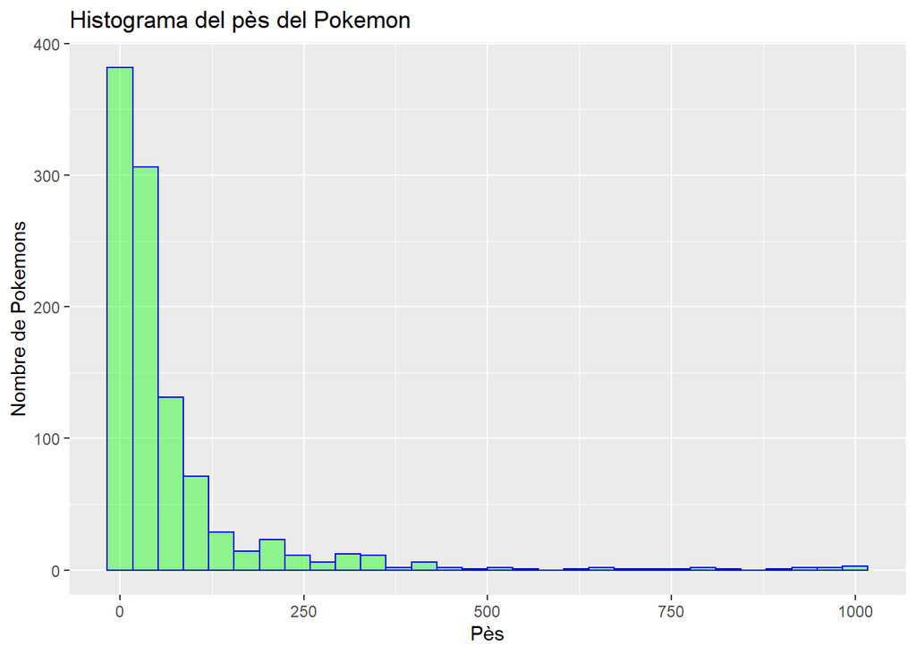

```r
gg <- ggplot(data=pokedex, aes(weight_kg)) +
      geom_histogram( col="blue", fill="green", alpha = .4) +
      labs(title="Histograma del pès del Pokemon") + labs(x="Pès", y="Nombre de Pokemons")
gg
```

Es pot observar que la majoria de Pokemons, són lleugers de pocs Kg.

##### Anàlisis de la variable abilities_number

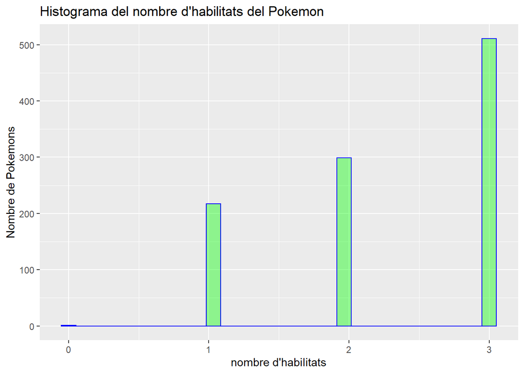

```r
gg <- ggplot(data=pokedex, aes(abilities_number)) +
      geom_histogram( col="blue", fill="green", alpha = .4) +
      labs(title="Histograma del nombre d'habilitats del Pokemon") + labs(x="nombre d'habilitats", y="Nombre de Pokemons")
gg
```

Es pot observar que la majoria de Pokemons tenen 3 habilitats.

#### Anàlisi de variables de tipus numèric informació de les estadístiques base

##### Anàlisis de la variable total-points

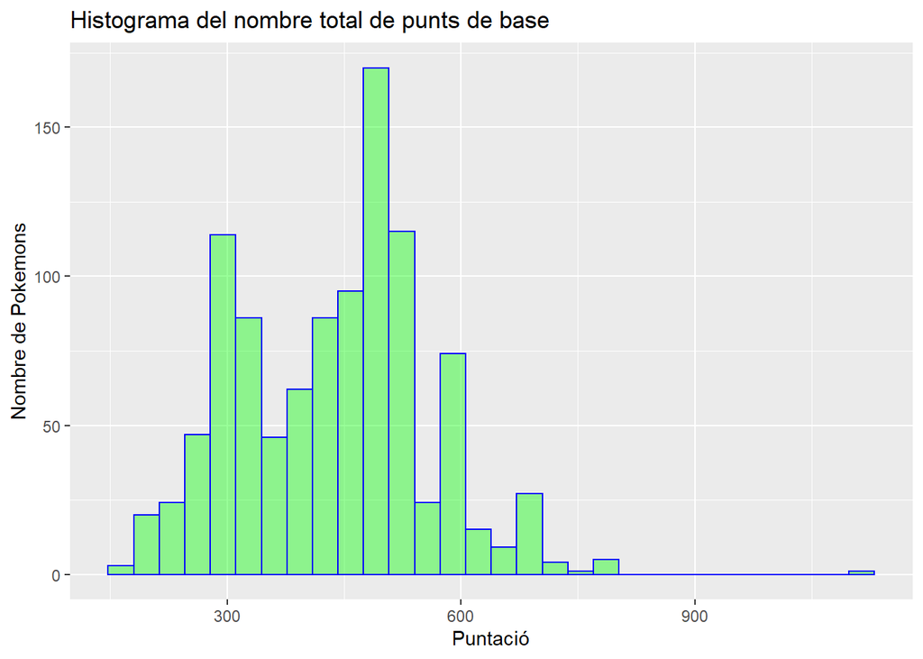

```r
gg <- ggplot(data=pokedex, aes(total_points)) +
      geom_histogram( col="blue", fill="green", alpha = .4) +
      labs(title="Histograma del nombre total de punts de base") + labs(x="Puntació", y="Nombre de Pokemons")
gg
```

Es pot observar que la majoria del pokemons estan entre 300 i 600 punts totals.

##### Anàlisis de la variable hp

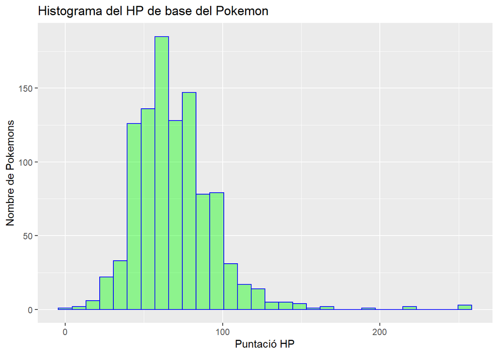

```r
gg <- ggplot(data=pokedex, aes(hp)) +
      geom_histogram( col="blue", fill="green", alpha = .4) +
      labs(title="Histograma del HP de base del Pokemon") + labs(x="Puntació HP", y="Nombre de Pokemons")
gg
```

Es pot observar que la majoria estan entre 50 i 100 punts d’HP.

##### Anàlisis de la variable attack

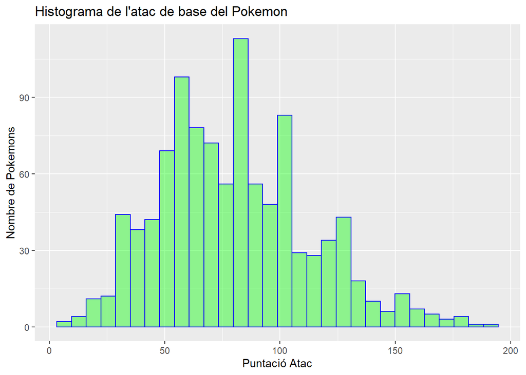

```r
gg <- ggplot(data=pokedex, aes(attack)) +
      geom_histogram( col="blue", fill="green", alpha = .4) +
      labs(title="Histograma de l'atac de base del Pokemon") + labs(x="Puntació Atac", y="Nombre de Pokemons")
gg
```

Es pot observar que la majoria estan entre 50 i 100 punts d’atac.

##### Anàlisis de la variable defense

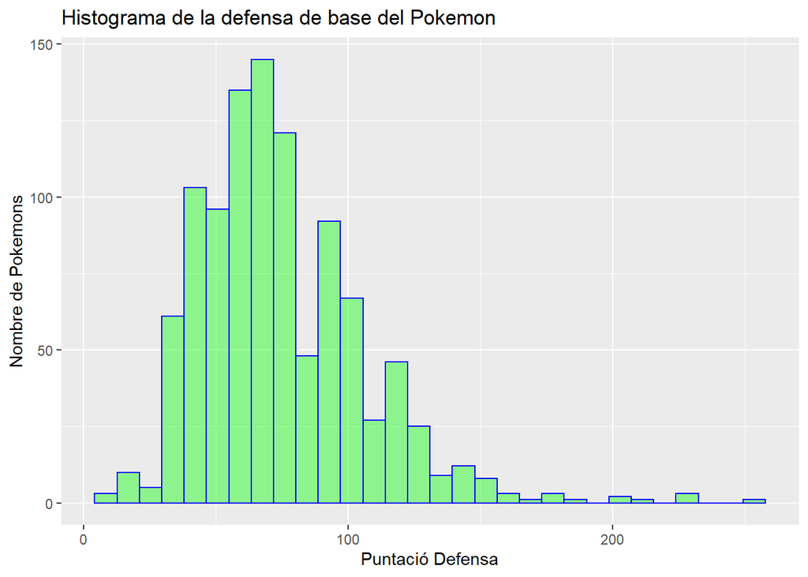

```r
gg <- ggplot(data=pokedex, aes(defense)) +
      geom_histogram( col="blue", fill="green", alpha = .4) +
      labs(title="Histograma de la defensa de base del Pokemon") + labs(x="Puntació Defensa", y="Nombre de Pokemons")
gg
```

Es pot observar que la majoria estan entre 50 i 75 punts de defensa

##### Anàlisis de la variable sp-attack

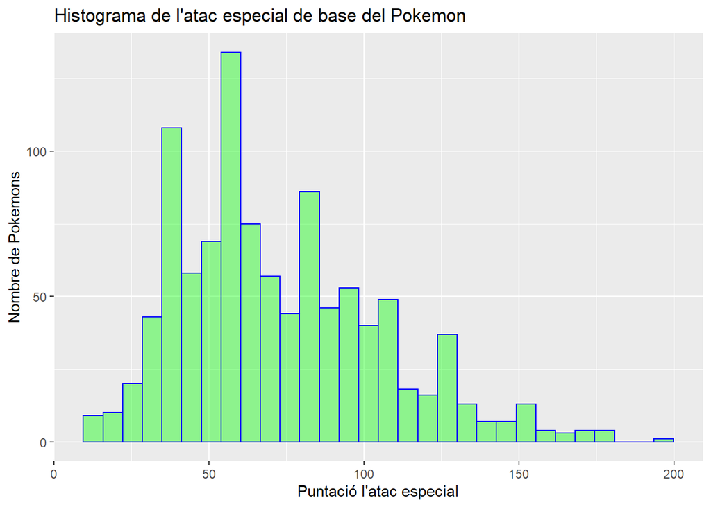

```r
gg <- ggplot(data=pokedex, aes(sp_attack)) +
      geom_histogram( col="blue", fill="green", alpha = .4) +
      labs(title="Histograma de l'atac especial de base del Pokemon") + labs(x="Puntació l'atac especial", y="Nombre de Pokemons")
gg
```

La majoria estan entre 50 i 100 punts d’atac especial.

##### Anàlisis de la variable sp-defense

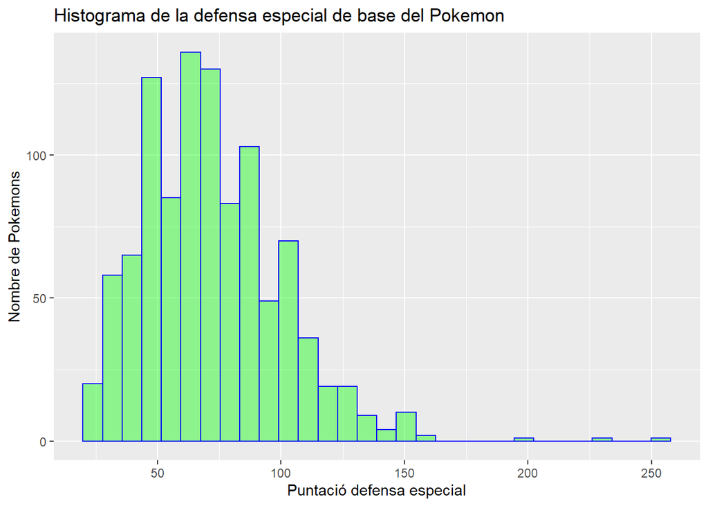

```r
gg <- ggplot(data=pokedex, aes(sp_defense)) +
      geom_histogram( col="blue", fill="green", alpha = .4) +
      labs(title="Histograma de la defensa especial de base del Pokemon") + labs(x="Puntació defensa especial", y="Nombre de Pokemons")
gg
```

La majoria estan entre 50 i 90 punts de defensa especial.

##### Anàlisis de la variable speed

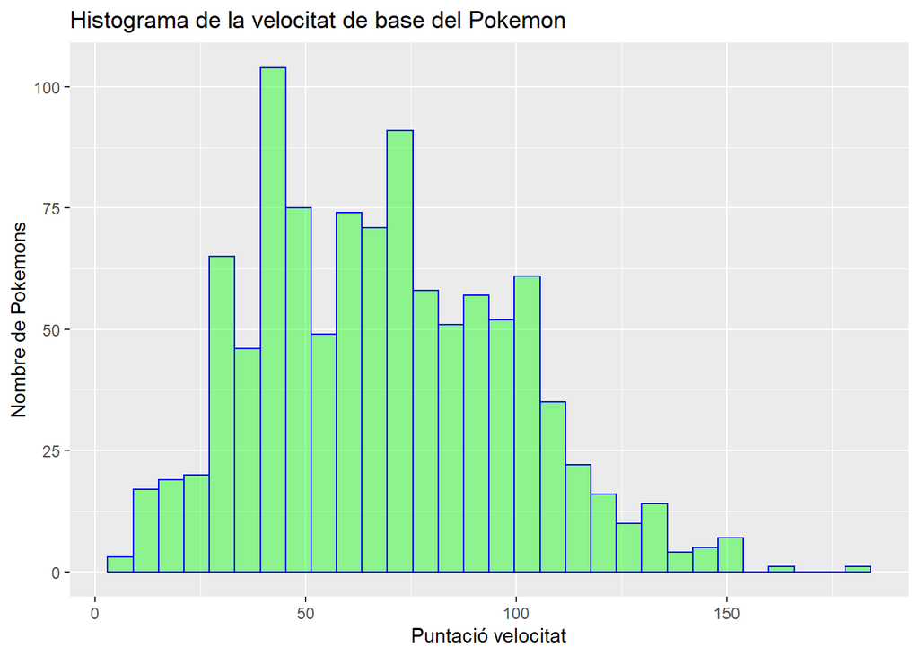

```r
gg <- ggplot(data=pokedex, aes(speed)) +
      geom_histogram( col="blue", fill="green", alpha = .4) +
      labs(title="Histograma de la velocitat de base del Pokemon") + labs(x="Puntació velocitat", y="Nombre de Pokemons")
gg
```

La majoria estan entre 25 i 100 punts de velocitat.

#### Distribució del total de punts

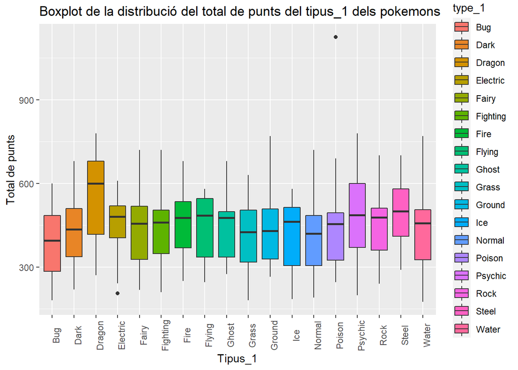

```r
p <- ggplot(pokedex, aes(x=type_1, y=total_points, fill=type_1)) + geom_boxplot()+
  labs(title="Boxplot de la distribució del total de punts del tipus_1 dels pokemons") +
  labs(x="Tipus_1", y="Total de punts")

p + theme(axis.text.x = element_text(angle = 90))
```

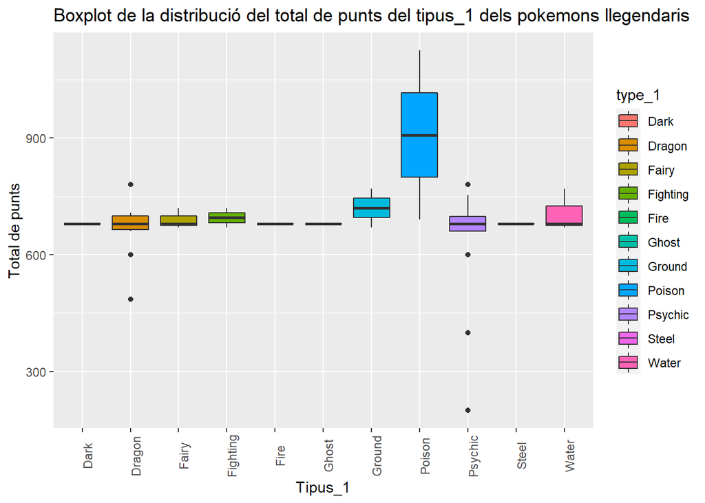

```r
pokedex %>%
  dplyr::filter(status == "Legendary") %>%

  ggplot(aes(x=type_1, y=total_points, fill=type_1)) + geom_boxplot()+
  labs(title="Boxplot de la distribució del total de punts del tipus_1 dels pokemons llegendaris") +
  labs(x="Tipus_1", y="Total de punts") + theme(axis.text.x = element_text(angle = 90))
```

```r
pokedexAnalysis <- subset(pokedex, select=c(status, type_number, type_1, type_2, height_m, weight_kg, abilities_number, ability_1, ability_2, total_points, hp, attack, defense, sp_attack, sp_defense, speed, catch_rate, base_friendship, base_experience, growth_rate,generation))
```

```r
head(pokedexAnalysis)
```

|  | status | type_number | type_1 | type_2 | height_m | weight_kg | abilities_number | ability_1 | ability_2 | total_points | hp | attack | defense | sp_attack | sp_defense | speed | catch_rate | base_friendship | base_experience | growth_rate | generation |
| --- | --- | --- | --- | --- | --- | --- | --- | --- | --- | --- | --- | --- | --- | --- | --- | --- | --- | --- | --- | --- | --- |
| 1 | Normal | 2 | Grass | Poison | 0.7 | 6.9 | 2 | Overgrow |  | 318 | 45 | 49 | 49 | 65 | 65 | 45 | 45 | 70 | 64 | Medium Slow | 1 |
| 2 | Normal | 2 | Grass | Poison | 1.0 | 13.0 | 2 | Overgrow |  | 405 | 60 | 62 | 63 | 80 | 80 | 60 | 45 | 70 | 142 | Medium Slow | 1 |
| 3 | Normal | 2 | Grass | Poison | 2.0 | 100.0 | 2 | Overgrow |  | 525 | 80 | 82 | 83 | 100 | 100 | 80 | 45 | 70 | 236 | Medium Slow | 1 |
| 4 | Normal | 2 | Grass | Poison | 2.4 | 155.5 | 1 | Thick Fat |  | 625 | 80 | 100 | 123 | 122 | 120 | 80 | 45 | 70 | 281 | Medium Slow | 1 |
| 5 | Normal | 1 | Fire |  | 0.6 | 8.5 | 2 | Blaze |  | 309 | 39 | 52 | 43 | 60 | 50 | 65 | 45 | 70 | 62 | Medium Slow | 1 |
| 6 | Normal | 1 | Fire |  | 1.1 | 19.0 | 2 | Blaze |  | 405 | 58 | 64 | 58 | 80 | 65 | 80 | 45 | 70 | 142 | Medium Slow | 1 |

## 3. Neteja de les dades.

### 3.1. Les dades contenen zeros o elements buits? Com gestionaries aquests casos?

Les dades contenen zeros, però no estan considerades com a valors absents. Amb l’anàlisi del summary, es podia veure que hi ha atributs que tenen valors absents:

- weight_kg: 1 NA
- catch_rate: 104 NA
- base_friendship: 104 NA
- base_experience: 104 NA
- percentage_male: 236 NA
- egg_cycles: 1 NA

Amb la reducció del dataset:

```r
sapply(pokedexAnalysis, function(x) sum(is.na(x)))
```

```
##           status      type_number           type_1           type_2
##                0                0                0                0
##         height_m        weight_kg abilities_number        ability_1
##                0                1                0                0
##        ability_2     total_points               hp           attack
##                0                0                0                0
##          defense        sp_attack       sp_defense            speed
##                0                0                0                0
##       catch_rate  base_friendship  base_experience      growth_rate
##              104              104              104                0
##       generation
##                0
```

En el cas de weight_kg, el substituirem a partir dels k-veïns més propers utilitzant la distància de Grower amb la informació de totes les variables. Els altres atributs absents, no els analitzarem. Ja que ens centrem l’anàlisi en altres atributs.

```r
library(VIM)
pokedexKNN <- kNN(pokedexAnalysis)
pokedexAnalysis$weight_kg <- pokedexKNN$weight_kg

### verifiquem que no te valors perduts
sum(is.na(pokedex$weight_kg))
```

```
## [1] 1
```

### 3.2. Identificació i tractament de valors extrems.

Els valors atípics o extrems, són les observacions que són numèricament distants de la resta de les observacions. A vegades poden indicar que aquests valors pertanyen a una població diferent de les mostres establertes.

A continuació analitzem els valors atípics:

```r
for(k in 1:ncol(pokedexAnalysis)){
  if(is.numeric(pokedexAnalysis[,k])){
    x <- boxplot.stats(pokedexAnalysis[,k])$out
    print(colnames(pokedexAnalysis[k]))
    print(x)
  }
}
```

```
## [1] "type_number"
## integer(0)
## [1] "height_m"
##  [1]   3.5   8.8  10.9   3.0   6.5   6.5   4.0   9.2  10.5   5.2   3.8  14.5
## [13]   6.2   4.5   9.8   3.5   5.0   7.0  10.8   5.4   4.2   3.7   4.5   6.9
## [25]   3.2   3.3   3.0   3.2   2.9   3.0   3.3   3.6   3.0   5.8   5.0   4.5
## [37]   6.5   8.2   3.0   3.9   3.4   4.0   3.8   9.2   5.5   3.8   4.2   7.5
## [49]   3.6   5.5   3.8   3.0   3.0   3.0   3.0   2.9   2.9  20.0 100.0
## [1] "weight_kg"
##   [1] 300.0 316.0 210.0 415.6 235.0 305.0 220.0 460.0 210.0 400.0 740.0 220.0
##  [13] 178.0 198.0 187.0 202.0 255.0 216.0 199.0 253.8 360.0 395.0 398.0 220.0
##  [25] 320.5 168.0 162.0 256.5 350.2 202.5 550.0 942.9 230.0 175.0 205.0 352.0
##  [37] 430.0 950.0 999.7 206.5 392.0 310.0 187.0 300.0 185.0 180.0 282.8 291.0
##  [49] 340.0 683.0 336.0 430.0 420.0 750.0 650.0 320.0 260.0 200.5 200.0 260.0
##  [61] 330.0 250.0 260.0 200.0 330.0 345.0 325.0 325.0 325.0 270.0 225.0 505.0
```

[output cut: 40 more lines]

No tractarem aquests valors extrems, degut a la tipologia de problema que estem tractant, com que hi ha tanta varietat d’espècies de Pokemon, aquests valors poden ser normals.

## 4. Anàlisi de les dades.

### 4.1. Selecció dels grups de dades que es volen analitzar/comparar (planificació dels anàlisis a aplicar).

Pels diferents anàlisis que es vol realitzar, es pretén analitzar els Pokemons per grups de classe separats: Tot el grup en general, per el seu estatus: normal, llegendari i sub llegendari i per tipus de pokemon: Bug, Dragon, Psychic, Steel i Poison. Aquests tipus de Pokemons, han estat seleccionats segons el que hem vist en els gràfics dels boxplots de distribució de total de punts i tipus_1. I de la variable status. Per tant haurem de crear diferents dataframes per poder fer els estudis corresponents.

Es generaran variables de tipus Factor tant de pes com d’alçada. Pes[lleuger,pesat] i Alçada[baix,alt], per poder realitzar test de 2 mostres amb el total_points.

```r
funcH <- function(h) {
  if(h <= 1.368 ){
    "baix"
  }else if(h > 1.368 ){
    "alt"
  }
}

funcW <- function(w) {
  if(w <= 69.75 ){
    "lleuger"
  }else if(w > 69.75 ){
    "pesat"
  }
}

##"height_m", "weight_kg"
pokedexAnalysis$Fheight_m <- as.factor(sapply(pokedexAnalysis$height_m,funcH))
pokedexAnalysis$Fweight_kg <- as.factor(sapply(pokedexAnalysis$weight_kg,funcW))

summary(pokedexAnalysis)
```

```
##            status     type_number        type_1        type_2
##  Legendary    : 39   Min.   :1.000   Water  :134          :486
##  Mythical     : 29   1st Qu.:1.000   Normal :115   Flying :109
##  Normal       :915   Median :2.000   Grass  : 91   Fairy  : 41
##  Sub Legendary: 45   Mean   :1.527   Bug    : 81   Ground : 39
##                      3rd Qu.:2.000   Psychic: 76   Poison : 38
##                      Max.   :2.000   Fire   : 65   Psychic: 38
##                                      (Other):466   (Other):277
##     height_m         weight_kg      abilities_number       ability_1
##  Min.   :  0.100   Min.   :  0.10   Min.   :0.000    Levitate   : 41
##  1st Qu.:  0.600   1st Qu.:  8.80   1st Qu.:2.000    Swift Swim : 30
##  Median :  1.000   Median : 28.65   Median :2.000    Keen Eye   : 28
##  Mean   :  1.368   Mean   : 70.03   Mean   :2.284    Chlorophyll: 25
##  3rd Qu.:  1.500   3rd Qu.: 70.00   3rd Qu.:3.000    Pressure   : 25
##  Max.   :100.000   Max.   :999.90   Max.   :3.000    Blaze      : 24
##                                                      (Other)    :855
##        ability_2    total_points          hp             attack
##             :515   Min.   : 175.0   Min.   :  1.00   Min.   :  5.00
##  Frisk      : 17   1st Qu.: 330.0   1st Qu.: 50.00   1st Qu.: 55.00
##  Sturdy     : 14   Median : 455.0   Median : 66.50   Median : 76.00
##  Shell Armor: 13   Mean   : 437.6   Mean   : 69.58   Mean   : 80.12
##  Early Bird : 10   3rd Qu.: 510.0   3rd Qu.: 80.00   3rd Qu.:100.00
##  Gluttony   : 10   Max.   :1125.0   Max.   :255.00   Max.   :190.00
##  (Other)    :449
##     defense         sp_attack        sp_defense         speed
##  Min.   :  5.00   Min.   : 10.00   Min.   : 20.00   Min.   :  5.00
##  1st Qu.: 50.00   1st Qu.: 50.00   1st Qu.: 50.00   1st Qu.: 45.00
##  Median : 70.00   Median : 65.00   Median : 70.00   Median : 65.00
##  Mean   : 74.48   Mean   : 72.73   Mean   : 72.13   Mean   : 68.53
##  3rd Qu.: 90.00   3rd Qu.: 95.00   3rd Qu.: 90.00   3rd Qu.: 90.00
##  Max.   :250.00   Max.   :194.00   Max.   :250.00   Max.   :180.00
##
##    catch_rate     base_friendship  base_experience      growth_rate
##  Min.   :  3.00   Min.   :  0.00   Min.   : 36.0              :  1
##  1st Qu.: 45.00   1st Qu.: 70.00   1st Qu.: 67.0   Erratic    : 26
##  Median : 60.00   Median : 70.00   Median :159.0   Fast       : 68
##  Mean   : 93.17   Mean   : 64.14   Mean   :153.8   Fluctuating: 14
##  3rd Qu.:127.00   3rd Qu.: 70.00   3rd Qu.:201.5   Medium Fast:432
##  Max.   :255.00   Max.   :140.00   Max.   :608.0   Medium Slow:245
##  NA's   :104      NA's   :104      NA's   :104     Slow       :242
##    generation    Fheight_m    Fweight_kg
##  Min.   :1.000   alt :340   lleuger:770
##  1st Qu.:2.000   baix:688   pesat  :258
##  Median :4.000
##  Mean   :4.034
##  3rd Qu.:6.000
##  Max.   :8.000
##
```

A continuació, generem els diferents dataframes, a partir del dataframe que prèviament s’ha netejat “pokedexAnalysis”:

```r
pokedexAnalysis.Legendary <-subset(pokedexAnalysis, status == 'Legendary')
pokedexAnalysis.SubLegendary <-subset(pokedexAnalysis, status == 'Sub Legendary')
pokedexAnalysis.Normal <-subset(pokedexAnalysis, status == 'Normal')
pokedexAnalysis.Bug <-subset(pokedexAnalysis, type_1 == 'Bug')
pokedexAnalysis.Dragon <-subset(pokedexAnalysis, type_1 == 'Dragon')
pokedexAnalysis.Psychic <-subset(pokedexAnalysis, type_1 == 'Psychic')
pokedexAnalysis.Poison <-subset(pokedexAnalysis, type_1 == 'Poison')
pokedexAnalysis.Steel <-subset(pokedexAnalysis, type_1 == 'Steel')
```

Els estudis a realitzar seran:

1. Estudiar les variables d’estadística base, que fan determinar la força total d’un Pokemon. Es vol estudiar la relació entre aquests atributs. S’estudiarà de forma global entre tots els tipus i llavors amb la classe Dragon i Bug, que són els més forts i dèbils respectivament. També estudiarem les classes Steel, Poison, Psychic. Influeix igual en els Pokemons llegendaris i sub llegendaris?
2. Estudiar si segons diferents tipus de pes i d’alçada del Pokemon, influeixen a que el Pokemon sigui més fort, per tant tinguin un total de punts més elevat.
3. Fer una predicció de com les variables d’estadística base, el pes i l’alçada influeixen amb la variable base_experience.

### 4.2. Comprovació de la normalitat i homogeneïtat de la variància.

Mitjançant la prova de normalitat *Shapiro-Wilk* comprovem la normalitat de les dades quantitatives. Si el p-valor és superior a 0,05 ho considerarem com distribució normal:

#### Compravació de la normalitat de tot el grup

```r
## definim taula de variables per els càlculs de la normalitat
analisi_normalitat <- c("height_m", "weight_kg","total_points", "hp", "attack", "defense", "sp_attack", "sp_defense", "speed")

## funció per calcular el test de Shapiro-Wilk
shapirotest <- function(x){
  alpha = 0.05
  p_val = shapiro.test(x)$p.value
  if (p_val > alpha) { "> 0.05" }
  else {"< 0.05"}
}
```

```r
apply(pokedexAnalysis[,analisi_normalitat], 2, shapirotest)
```

```
##     height_m    weight_kg total_points           hp       attack      defense
##     "< 0.05"     "< 0.05"     "< 0.05"     "< 0.05"     "< 0.05"     "< 0.05"
##    sp_attack   sp_defense        speed
##     "< 0.05"     "< 0.05"     "< 0.05"
```

Un cop vistos els resultats, es comprova que no hi ha cap variable que segueix una distribució normal, s’aplicarà el test de Spearman per calcular les correlacions entre parells de variables:

```r
corr.general<-cor(pokedexAnalysis[,analisi_normalitat], method="spearman")
corr.general
```

```
##               height_m weight_kg total_points        hp    attack    defense
## height_m     1.0000000 0.8445423    0.7271834 0.6421040 0.6229499 0.50081658
## weight_kg    0.8445423 1.0000000    0.6429082 0.6107825 0.5870074 0.53268085
## total_points 0.7271834 0.6429082    1.0000000 0.7224800 0.7253079 0.67868217
## hp           0.6421040 0.6107825    0.7224800 1.0000000 0.5793900 0.45752740
## attack       0.6229499 0.5870074    0.7253079 0.5793900 1.0000000 0.51463234
## defense      0.5008166 0.5326808    0.6786822 0.4575274 0.5146323 1.00000000
## sp_attack    0.4750580 0.3411488    0.7293632 0.4737787 0.3535374 0.31669441
## sp_defense   0.4941680 0.4432568    0.7464024 0.4922686 0.3216803 0.59515716
## speed        0.3278843 0.1916601    0.5454881 0.2674212 0.3658956 0.06822903
##              sp_attack sp_defense      speed
## height_m     0.4750580  0.4941680 0.32788433
## weight_kg    0.3411488  0.4432568 0.19166008
## total_points 0.7293632  0.7464024 0.54548811
## hp           0.4737787  0.4922686 0.26742123
## attack       0.3535374  0.3216803 0.36589561
## defense      0.3166944  0.5951572 0.06822903
## sp_attack    1.0000000  0.5783745 0.43790817
## sp_defense   0.5783745  1.0000000 0.27996316
## speed        0.4379082  0.2799632 1.00000000
```

No s’identifica cap correlació negativa. El parell de variables que estan més correlacionades són weight_kg i height_m. La que menys defense i speed.

#### Compravació de la normalitat dels Llegendaris

```r
apply(pokedexAnalysis.Legendary[,analisi_normalitat], 2, shapirotest)
```

```
##     height_m    weight_kg total_points           hp       attack      defense
##     "< 0.05"     "< 0.05"     "< 0.05"     "< 0.05"     "< 0.05"     "< 0.05"
##    sp_attack   sp_defense        speed
##     "> 0.05"     "< 0.05"     "< 0.05"
```

Un cop vistos els resultats, es comprova que hi ha una variable que compleix la distribució normal: sp_attack. La resta no segueixen una distribució normal, s’aplicarà el test de Spearman per calcular les correlacions entre parells de variables:

```r
corr.legendary<-cor(pokedexAnalysis.Legendary[,analisi_normalitat], method="spearman")
corr.legendary
```

```
##                 height_m    weight_kg total_points          hp       attack
## height_m      1.00000000  0.397983487   0.39192759  0.45774863  0.053911459
## weight_kg     0.39798349  1.000000000   0.21754689  0.04250495  0.002593459
## total_points  0.39192759  0.217546890   1.00000000  0.33977698  0.539091466
## hp            0.45774863  0.042504951   0.33977698  1.00000000 -0.043127258
## attack        0.05391146  0.002593459   0.53909147 -0.04312726  1.000000000
## defense       0.13847321  0.622322099   0.08670783 -0.07119840  0.046906159
## sp_attack     0.37588954 -0.021325265   0.53442491  0.22852115  0.348675229
## sp_defense    0.17587644  0.217866441   0.27255534 -0.08076060 -0.068372144
## speed        -0.04348917 -0.366430094   0.37948600  0.09000829  0.264254457
##                  defense   sp_attack  sp_defense       speed
## height_m      0.13847321  0.37588954  0.17587644 -0.04348917
## weight_kg     0.62232210 -0.02132527  0.21786644 -0.36643009
## total_points  0.08670783  0.53442491  0.27255534  0.37948600
## hp           -0.07119840  0.22852115 -0.08076060  0.09000829
## attack        0.04690616  0.34867523 -0.06837214  0.26425446
## defense       1.00000000 -0.38957318  0.22458477 -0.13148454
## sp_attack    -0.38957318  1.00000000  0.06694209  0.09998229
## sp_defense    0.22458477  0.06694209  1.00000000  0.07910543
## speed        -0.13148454  0.09998229  0.07910543  1.00000000
```

#### Compravació de la normalitat dels Sub Llegendaris

```r
apply(pokedexAnalysis.SubLegendary[,analisi_normalitat], 2, shapirotest)
```

```
##     height_m    weight_kg total_points           hp       attack      defense
##     "< 0.05"     "< 0.05"     "< 0.05"     "< 0.05"     "> 0.05"     "< 0.05"
##    sp_attack   sp_defense        speed
##     "> 0.05"     "> 0.05"     "< 0.05"
```

Un cop vistos els resultats, es comprova que hi ha variables que compleixen la distribució normal: attack, sp_attack, sp_defense, la resta no segueixen una distribució normal, s’aplicarà el test de Spearman per calcular les correlacions entre parells de variables:

```r
corr.sublegendary<-cor(pokedexAnalysis.SubLegendary[,analisi_normalitat], method="spearman")
corr.sublegendary
```

```
##                 height_m   weight_kg total_points         hp      attack
## height_m      1.00000000  0.71482100  -0.10937888  0.3871261  0.16353412
## weight_kg     0.71482100  1.00000000   0.11100220  0.6388801  0.03552098
## total_points -0.10937888  0.11100220   1.00000000  0.2828191  0.05984086
## hp            0.38712613  0.63888006   0.28281908  1.0000000 -0.13130977
## attack        0.16353412  0.03552098   0.05984086 -0.1313098  1.00000000
## defense       0.06658291  0.25794445   0.22539803  0.1094882  0.02799723
## sp_attack     0.00493100 -0.27465462   0.14757320 -0.1512102 -0.04418428
## sp_defense   -0.13084183  0.05104435   0.42070355  0.1621842 -0.51125440
## speed        -0.18535069 -0.36658769   0.21668816 -0.2527418  0.18146071
##                  defense   sp_attack  sp_defense      speed
## height_m      0.06658291  0.00493100 -0.13084183 -0.1853507
## weight_kg     0.25794445 -0.27465462  0.05104435 -0.3665877
## total_points  0.22539803  0.14757320  0.42070355  0.2166882
## hp            0.10948823 -0.15121015  0.16218425 -0.2527418
## attack        0.02799723 -0.04418428 -0.51125440  0.1814607
## defense       1.00000000 -0.60343810  0.39018105 -0.4554884
## sp_attack    -0.60343810  1.00000000 -0.03616290  0.4414847
## sp_defense    0.39018105 -0.03616290  1.00000000 -0.2186953
## speed        -0.45548840  0.44148474 -0.21869530  1.0000000
```

Es pot observar que hi ha bastantes correlacions negatives poc significatives. El parell de variables que estan més correlacionades són el weight_kg i el height_m. La que menys sp_attack i height_m.

#### Compravació de la normalitat dels Normal

```r
apply(pokedexAnalysis.Normal[,analisi_normalitat], 2, shapirotest)
```

```
##     height_m    weight_kg total_points           hp       attack      defense
##     "< 0.05"     "< 0.05"     "< 0.05"     "< 0.05"     "< 0.05"     "< 0.05"
##    sp_attack   sp_defense        speed
##     "< 0.05"     "< 0.05"     "< 0.05"
```

Un cop vistos els resultats, es comprova que no hi ha cap variable que segueix una distribució normal, s’aplicarà el test de Spearman per calcular les correlacions entre parells de variables:

```r
corr.normal<-cor(pokedexAnalysis.Normal[,analisi_normalitat], method="spearman")
corr.normal
```

```
##               height_m weight_kg total_points        hp    attack     defense
## height_m     1.0000000 0.8247715    0.7294372 0.6406068 0.6087376  0.49122801
## weight_kg    0.8247715 1.0000000    0.6430732 0.6048420 0.5854619  0.51876330
## total_points 0.7294372 0.6430732    1.0000000 0.7025326 0.6892365  0.66387254
## hp           0.6406068 0.6048420    0.7025326 1.0000000 0.5569196  0.42615584
## attack       0.6087376 0.5854619    0.6892365 0.5569196 1.0000000  0.49535542
## defense      0.4912280 0.5187633    0.6638725 0.4261558 0.4953554  1.00000000
## sp_attack    0.4257457 0.2898501    0.6768441 0.4164971 0.2645908  0.27263737
## sp_defense   0.4787056 0.4163457    0.7299270 0.4515667 0.2715467  0.56427825
## speed        0.2793456 0.1440665    0.4658765 0.1905804 0.2876544 -0.01377796
##              sp_attack sp_defense       speed
## height_m     0.4257457  0.4787056  0.27934563
## weight_kg    0.2898501  0.4163457  0.14406653
## total_points 0.6768441  0.7299270  0.46587645
## hp           0.4164971  0.4515667  0.19058041
## attack       0.2645908  0.2715467  0.28765440
## defense      0.2726374  0.5642783 -0.01377796
## sp_attack    1.0000000  0.5467666  0.35072172
## sp_defense   0.5467666  1.0000000  0.20985845
## speed        0.3507217  0.2098584  1.00000000
```

#### Compravació de la normalitat dels Bug

```r
apply(pokedexAnalysis.Bug[,analisi_normalitat], 2, shapirotest)
```

```
##     height_m    weight_kg total_points           hp       attack      defense
##     "< 0.05"     "< 0.05"     "< 0.05"     "> 0.05"     "< 0.05"     "< 0.05"
##    sp_attack   sp_defense        speed
##     "< 0.05"     "< 0.05"     "< 0.05"
```

Un cop vistos els resultats, es comprova que hi ha una variable que compleix la distribució normal: hp. La resta no segueixen una distribució normal, s’aplicarà el test de Spearman per calcular les correlacions entre parells de variables:

```r
corr.bug<-cor(pokedexAnalysis.Bug[,analisi_normalitat], method="spearman")
corr.bug
```

```
##               height_m weight_kg total_points        hp    attack     defense
## height_m     1.0000000 0.8437690    0.7040183 0.7377776 0.6478494  0.38552800
## weight_kg    0.8437690 1.0000000    0.7367446 0.6937745 0.6279671  0.55983381
## total_points 0.7040183 0.7367446    1.0000000 0.8134250 0.7478347  0.63848409
## hp           0.7377776 0.6937745    0.8134250 1.0000000 0.7039882  0.42063760
## attack       0.6478494 0.6279671    0.7478347 0.7039882 1.0000000  0.47323396
## defense      0.3855280 0.5598338    0.6384841 0.4206376 0.4732340  1.00000000
## sp_attack    0.4660880 0.3975147    0.6814673 0.7223940 0.4660845  0.31791174
## sp_defense   0.4737494 0.5357487    0.7173375 0.5109216 0.3938180  0.58026635
## speed        0.4147443 0.3741652    0.5637374 0.5043968 0.4089315 -0.05941105
##              sp_attack sp_defense       speed
## height_m     0.4660880  0.4737494  0.41474434
## weight_kg    0.3975147  0.5357487  0.37416515
## total_points 0.6814673  0.7173375  0.56373745
## hp           0.7223940  0.5109216  0.50439681
## attack       0.4660845  0.3938180  0.40893152
## defense      0.3179117  0.5802663 -0.05941105
## sp_attack    1.0000000  0.5015327  0.48380282
## sp_defense   0.5015327  1.0000000  0.23134780
## speed        0.4838028  0.2313478  1.00000000
```

#### Compravació de la normalitat dels Dragon

```r
apply(pokedexAnalysis.Dragon[,analisi_normalitat], 2, shapirotest)
```

```
##     height_m    weight_kg total_points           hp       attack      defense
##     "< 0.05"     "< 0.05"     "< 0.05"     "< 0.05"     "> 0.05"     "> 0.05"
##    sp_attack   sp_defense        speed
##     "> 0.05"     "> 0.05"     "> 0.05"
```

Un cop vistos els resultats, es comprova que hi ha variables que compleixen la distribució normal: attack, defense, sp_attack, sp_defense, speed, i la resta no segueixen una distribució normal, s’aplicarà el test de Spearman per calcular les correlacions entre parells de variables:

```r
corr.dragon<-cor(pokedexAnalysis.Dragon[,analisi_normalitat], method="spearman")
corr.dragon
```

```
##               height_m weight_kg total_points        hp    attack   defense
## height_m     1.0000000 0.7347459    0.7893448 0.8095194 0.6738980 0.5690797
## weight_kg    0.7347459 1.0000000    0.7822978 0.8438520 0.7635649 0.7108920
## total_points 0.7893448 0.7822978    1.0000000 0.8965642 0.7753509 0.7963697
## hp           0.8095194 0.8438520    0.8965642 1.0000000 0.7728194 0.6904454
## attack       0.6738980 0.7635649    0.7753509 0.7728194 1.0000000 0.6523358
## defense      0.5690797 0.7108920    0.7963697 0.6904454 0.6523358 1.0000000
## sp_attack    0.7426935 0.6413536    0.9075369 0.7789917 0.6584228 0.6404532
## sp_defense   0.4822250 0.4338082    0.7130383 0.5745447 0.3513998 0.5814557
## speed        0.5256522 0.3675060    0.6775899 0.5707225 0.5638574 0.4351033
##              sp_attack sp_defense     speed
## height_m     0.7426935  0.4822250 0.5256522
## weight_kg    0.6413536  0.4338082 0.3675060
## total_points 0.9075369  0.7130383 0.6775899
## hp           0.7789917  0.5745447 0.5707225
## attack       0.6584228  0.3513998 0.5638574
## defense      0.6404532  0.5814557 0.4351033
## sp_attack    1.0000000  0.7877817 0.6436413
## sp_defense   0.7877817  1.0000000 0.4090417
## speed        0.6436413  0.4090417 1.0000000
```

Es pot observar que no hi ha correlacions negatives. El parell de variables que estan més correlacionades són el sp_attack i total_points. La que menys attack i sp_defense.

#### Compravació de la normalitat dels Steel

```r
apply(pokedexAnalysis.Steel[,analisi_normalitat], 2, shapirotest)
```

```
##     height_m    weight_kg total_points           hp       attack      defense
##     "< 0.05"     "< 0.05"     "> 0.05"     "< 0.05"     "> 0.05"     "< 0.05"
##    sp_attack   sp_defense        speed
##     "< 0.05"     "> 0.05"     "< 0.05"
```

Un cop vistos els resultats, es comprova que hi ha variables que compleixen la distribució normal: total_points, attack, sp_defense, i la resta no segueixen una distribució normal, s’aplicarà el test de Spearman per calcular les correlacions entre parells de variables:

```r
corr.steel<-cor(pokedexAnalysis.Steel[,analisi_normalitat], method="spearman")
corr.steel
```

```
##               height_m  weight_kg total_points        hp    attack   defense
## height_m     1.0000000 0.81106274    0.6974041 0.7199121 0.5801847 0.6091874
## weight_kg    0.8110627 1.00000000    0.5855208 0.6721461 0.4558946 0.4687492
## total_points 0.6974041 0.58552084    1.0000000 0.8046392 0.7245656 0.6544974
## hp           0.7199121 0.67214612    0.8046392 1.0000000 0.6128257 0.4151613
## attack       0.5801847 0.45589459    0.7245656 0.6128257 1.0000000 0.3928133
## defense      0.6091874 0.46874918    0.6544974 0.4151613 0.3928133 1.0000000
## sp_attack    0.4393772 0.38285900    0.7770171 0.6744308 0.6274037 0.1680696
## sp_defense   0.3503098 0.40413777    0.6309232 0.4926555 0.1683993 0.4182278
## speed        0.1598787 0.05476435    0.5891575 0.4181469 0.3519767 0.1930840
##              sp_attack sp_defense      speed
## height_m     0.4393772  0.3503098 0.15987866
## weight_kg    0.3828590  0.4041378 0.05476435
## total_points 0.7770171  0.6309232 0.58915747
## hp           0.6744308  0.4926555 0.41814689
## attack       0.6274037  0.1683993 0.35197669
## defense      0.1680696  0.4182278 0.19308396
## sp_attack    1.0000000  0.4832484 0.66285267
## sp_defense   0.4832484  1.0000000 0.42909192
## speed        0.6628527  0.4290919 1.00000000
```

Es pot observar que no hi ha correlacions negatives. El parell de variables que estan més correlacionades són el weight_kg i height_m. La que menys speed i weight_kg.

#### Compravació de la normalitat dels Poison

```r
apply(pokedexAnalysis.Poison[,analisi_normalitat], 2, shapirotest)
```

```
##     height_m    weight_kg total_points           hp       attack      defense
##     "< 0.05"     "< 0.05"     "< 0.05"     "< 0.05"     "> 0.05"     "< 0.05"
##    sp_attack   sp_defense        speed
##     "< 0.05"     "< 0.05"     "< 0.05"
```

Un cop vistos els resultats, es comprova que hi ha una variable que compleix la distribució normal: attack. La resta no segueixen una distribució normal, s’aplicarà el test de Spearman per calcular les correlacions entre parells de variables:

```r
corr.poison<-cor(pokedexAnalysis.Poison[,analisi_normalitat], method="spearman")
corr.poison
```

```
##               height_m weight_kg total_points        hp    attack   defense
## height_m     1.0000000 0.7402520    0.6928509 0.5095222 0.6855361 0.5120296
## weight_kg    0.7402520 1.0000000    0.7136130 0.7318304 0.6686769 0.4432401
## total_points 0.6928509 0.7136130    1.0000000 0.7142207 0.7621680 0.7857976
## hp           0.5095222 0.7318304    0.7142207 1.0000000 0.7628882 0.3893878
## attack       0.6855361 0.6686769    0.7621680 0.7628882 1.0000000 0.5254831
## defense      0.5120296 0.4432401    0.7857976 0.3893878 0.5254831 1.0000000
## sp_attack    0.6484030 0.5314066    0.7509551 0.5605338 0.6100252 0.4839936
## sp_defense   0.6637541 0.6925583    0.8661734 0.6330220 0.6815553 0.7906838
## speed        0.5784235 0.5302384    0.5798126 0.3975836 0.4134484 0.2834602
##              sp_attack sp_defense     speed
## height_m     0.6484030  0.6637541 0.5784235
## weight_kg    0.5314066  0.6925583 0.5302384
## total_points 0.7509551  0.8661734 0.5798126
## hp           0.5605338  0.6330220 0.3975836
## attack       0.6100252  0.6815553 0.4134484
## defense      0.4839936  0.7906838 0.2834602
## sp_attack    1.0000000  0.5841011 0.5776554
## sp_defense   0.5841011  1.0000000 0.3752602
## speed        0.5776554  0.3752602 1.0000000
```

Es pot observar que no hi ha correlacions negatives. El parell de variables que estan més correlacionades són el total_points i sp_defense. La que menys speed i defense.

#### Compravació de la normalitat dels Psychic

```r
apply(pokedexAnalysis.Psychic[,analisi_normalitat], 2, shapirotest)
```

```
##     height_m    weight_kg total_points           hp       attack      defense
##     "< 0.05"     "< 0.05"     "> 0.05"     "< 0.05"     "< 0.05"     "< 0.05"
##    sp_attack   sp_defense        speed
##     "> 0.05"     "> 0.05"     "> 0.05"
```

Un cop vistos els resultats, es comprova que hi ha variables que compleixen la distribució normal: total_points, sp_attack, sp_defense, speed, i la resta no segueixen una distribució normal, s’aplicarà el test de Spearman per calcular les correlacions entre parells de variables:

```r
corr.psychic<-cor(pokedexAnalysis.Psychic[,analisi_normalitat], method="spearman")
corr.psychic
```

```
##               height_m weight_kg total_points        hp    attack   defense
## height_m     1.0000000 0.8287837    0.6798441 0.3613326 0.5936483 0.3732094
## weight_kg    0.8287837 1.0000000    0.5575698 0.2950586 0.4152088 0.3430801
## total_points 0.6798441 0.5575698    1.0000000 0.6304778 0.8883465 0.7051373
## hp           0.3613326 0.2950586    0.6304778 1.0000000 0.5269098 0.6331338
## attack       0.5936483 0.4152088    0.8883465 0.5269098 1.0000000 0.5751413
## defense      0.3732094 0.3430801    0.7051373 0.6331338 0.5751413 1.0000000
## sp_attack    0.5229052 0.3479175    0.7025825 0.3525706 0.6004285 0.2706368
## sp_defense   0.4430197 0.4860795    0.6761585 0.4349801 0.4578954 0.6822322
## speed        0.4282293 0.3190631    0.6543700 0.1634030 0.5790353 0.2810258
##              sp_attack sp_defense     speed
## height_m     0.5229052  0.4430197 0.4282293
## weight_kg    0.3479175  0.4860795 0.3190631
## total_points 0.7025825  0.6761585 0.6543700
## hp           0.3525706  0.4349801 0.1634030
## attack       0.6004285  0.4578954 0.5790353
## defense      0.2706368  0.6822322 0.2810258
## sp_attack    1.0000000  0.3535881 0.4735736
## sp_defense   0.3535881  1.0000000 0.2653745
## speed        0.4735736  0.2653745 1.0000000
```

#### Comprovació de la homogenietat

Per mirar la homogenietat, utilitzarem el test *Fligner-killen* per comparar les variables amb distribució normal, sinó utilitzarem el test *Kruskal-wallis*.

```r
## definim taula de variables per els càlculs de la normalitat i de la homogeneïtat de la variànça
analisi_homogenietat <- c("height_m", "weight_kg","hp", "attack", "defense", "sp_attack", "sp_defense", "speed")
total_points <- c("height_m", "weight_kg","hp", "attack", "defense", "sp_attack", "sp_defense", "speed")

## funció per calcular el test de kruskal-wallis
kruskaltest <- function(y,x){
  alpha = 0.05
  p_val = kruskal.test(x ~ y)$p.value
  if (p_val > alpha) { "> 0.05"}
  else { "< 0.05"}
}
```

##### Comprovació de la homogenietat de tot el grup

Com que totes les variables no tenien una distribució normal, aplicarem el test de Kruskal-wallis per veure el seu comportament, entre el total_points i la resta de variables:

```r
sapply(pokedexAnalysis[,analisi_normalitat], kruskaltest, pokedexAnalysis$total_points)
```

```
##     height_m    weight_kg total_points           hp       attack      defense
##     "< 0.05"     "< 0.05"     "< 0.05"     "< 0.05"     "< 0.05"     "< 0.05"
##    sp_attack   sp_defense        speed
##     "< 0.05"     "< 0.05"     "< 0.05"
```

Es pot observar que cap variable la p > 0.05. No podem acceptar la hipòtesis de que les variances del total de punts amb la resta són homogènies.

##### Comprovació de la homogenietat de Llegendaris

Com que totes les variables no tenien una distribució normal, aplicarem el test de Kruskal-wallis per veure el seu comportament, entre el total_points i la resta de variables:

```r
sapply(pokedexAnalysis.Legendary[,analisi_homogenietat], kruskaltest, pokedexAnalysis.Legendary$total_points)
```

```
##   height_m  weight_kg         hp     attack    defense  sp_attack sp_defense
##   "> 0.05"   "> 0.05"   "> 0.05"   "> 0.05"   "> 0.05"   "> 0.05"   "> 0.05"
##      speed
##   "> 0.05"
```

Es pot observar que totes les variables la p > 0.05. Podem acceptar la hipòtesis de que les variances del total de punts amb la resta són homogènies.

##### Comprovació de la homogenietat de Sub Llegendaris

Com que totes les variables no tenien una distribució normal, aplicarem el test de Kruskal-wallis per veure el seu comportament, entre el total_points i la resta de variables:

```r
sapply(pokedexAnalysis.SubLegendary[,analisi_homogenietat], kruskaltest, pokedexAnalysis.SubLegendary$total_points)
```

```
##   height_m  weight_kg         hp     attack    defense  sp_attack sp_defense
##   "> 0.05"   "> 0.05"   "< 0.05"   "> 0.05"   "> 0.05"   "> 0.05"   "> 0.05"
##      speed
##   "> 0.05"
```

Es pot observar que totes les variables menys la “hp”, la p > 0.05. Podem acceptar la hipòtesis de que les variances del total de punts amb la resta són homogènies.

##### Comprovació de la homogenietat de Normal

Com que totes les variables no tenien una distribució normal, aplicarem el test de Kruskal-wallis per veure el seu comportament, entre el total_points i la resta de variables:

```r
sapply(pokedexAnalysis.Normal[,analisi_homogenietat], kruskaltest, pokedexAnalysis.Normal$total_points)
```

```
##   height_m  weight_kg         hp     attack    defense  sp_attack sp_defense
##   "< 0.05"   "< 0.05"   "< 0.05"   "< 0.05"   "< 0.05"   "< 0.05"   "< 0.05"
##      speed
##   "< 0.05"
```

Es pot observar que cap variable la p > 0.05. No podem acceptar la hipòtesis de que les variances del total de punts amb la resta són homogènies.

##### Comprovació de la homogenietat del tipus Bug

Com que totes les variables no tenien una distribució normal, aplicarem el test de Kruskal-wallis per veure el seu comportament, entre el total_points i la resta de variables:

```r
sapply(pokedexAnalysis.Bug[,analisi_homogenietat], kruskaltest, pokedexAnalysis.Bug$total_points)
```

```
##   height_m  weight_kg         hp     attack    defense  sp_attack sp_defense
##   "< 0.05"   "> 0.05"   "< 0.05"   "< 0.05"   "< 0.05"   "< 0.05"   "< 0.05"
##      speed
##   "< 0.05"
```

Es pot observar que només hi ha la variable “weight_kg” on la p > 0.05. Només podem acceptar la hipòtesis de que les variàncies del total de punts amb la resta són homogènies, en la variable “weight_kg” respecte “total_points”.

##### Comprovació de la homogenietat del tipus Dragon

Com que totes les variables no tenien una distribució normal, aplicarem el test de Kruskal-wallis per veure el seu comportament, entre el total_points i la resta de variables:

```r
sapply(pokedexAnalysis.Dragon[,analisi_homogenietat], kruskaltest, pokedexAnalysis.Dragon$total_points)
```

```
##   height_m  weight_kg         hp     attack    defense  sp_attack sp_defense
##   "> 0.05"   "> 0.05"   "< 0.05"   "> 0.05"   "> 0.05"   "< 0.05"   "< 0.05"
##      speed
##   "> 0.05"
```

Es pot observar que totes les variables menys la “hp”,“sp_attack” i “sp_defense”, la p > 0.05. Podem acceptar la hipòtesis de que les variàncies del total de punts amb la resta són homogènies, en les variables que tenen la p > 0.05.

##### Comprovació de la homogenietat del tipus Steel

Com que totes les variables no tenien una distribució normal, aplicarem el test de Kruskal-wallis per veure el seu comportament, entre el total_points i la resta de variables:

```r
sapply(pokedexAnalysis.Steel[,analisi_homogenietat], kruskaltest, pokedexAnalysis.Steel$total_points)
```

```
##   height_m  weight_kg         hp     attack    defense  sp_attack sp_defense
##   "> 0.05"   "> 0.05"   "< 0.05"   "> 0.05"   "> 0.05"   "> 0.05"   "> 0.05"
##      speed
##   "> 0.05"
```

Es pot observar que totes les variables menys la “hp”, la p > 0.05. Podem acceptar la hipòtesis de que les variances del total de punts amb la resta són homogènies.

##### Comprovació de la homogenietat del tipus Poison

```r
sapply(pokedexAnalysis.Poison[,analisi_homogenietat], kruskaltest, pokedexAnalysis.Poison$total_points)
```

```
##   height_m  weight_kg         hp     attack    defense  sp_attack sp_defense
##   "< 0.05"   "> 0.05"   "> 0.05"   "> 0.05"   "> 0.05"   "< 0.05"   "> 0.05"
##      speed
##   "> 0.05"
```

Es pot observar que totes les variables menys la “height_m” i “sp_attack”, la p > 0.05. Podem acceptar la hipòtesis de que les variàncies del total de punts amb la resta són homogènies, només en les que la p > 0.05.

##### Comprovació de la homogenietat del tipus Psychic

```r
sapply(pokedexAnalysis.Psychic[,analisi_homogenietat], kruskaltest, pokedexAnalysis.Psychic$total_points)
```

```
##   height_m  weight_kg         hp     attack    defense  sp_attack sp_defense
##   "< 0.05"   "> 0.05"   "< 0.05"   "< 0.05"   "< 0.05"   "> 0.05"   "< 0.05"
##      speed
##   "< 0.05"
```

Es pot observar que nomes les variables “weight_kg” i “sp_attack”, la p > 0.05. Podem acceptar la hipòtesis de que les variàncies del total de punts amb la resta són homogènies, només en les que la p> 0.05.

### 4.3. Aplicació de proves estadístiques per comparar els grups de dades. En funció de les dades i de l’objectiu de l’estudi, aplicar proves de contrast d’hipòtesis, correlacions, regressions, etc. Aplicar almenys tres mètodes d’anàlisi diferents.

#### 4.3.1. Estudiar les variables d’estadística base, que fan determinar la força total d’un Pokemon. Es vol estudiar la relació entre aquests atributs. S’estudiarà de forma global entre tots els tipus i llavors amb la classe Dragon i Bug, que són els més forts i dèbils respectivament. També estudiarem les classes Steel, Poison, Psychic. Influeix igual en els Pokemons llegendaris i sub llegendaris?

Com que per estudiar la normalitat de les dades s’han realitzat les matrius de correlació, les mostrarem i estudiarem la importància de les variables segons el total_points:

##### Matriu de correlació dels Pokemons en general

```r
corr.general
```

```
##               height_m weight_kg total_points        hp    attack    defense
## height_m     1.0000000 0.8445423    0.7271834 0.6421040 0.6229499 0.50081658
## weight_kg    0.8445423 1.0000000    0.6429082 0.6107825 0.5870074 0.53268085
## total_points 0.7271834 0.6429082    1.0000000 0.7224800 0.7253079 0.67868217
## hp           0.6421040 0.6107825    0.7224800 1.0000000 0.5793900 0.45752740
## attack       0.6229499 0.5870074    0.7253079 0.5793900 1.0000000 0.51463234
## defense      0.5008166 0.5326808    0.6786822 0.4575274 0.5146323 1.00000000
## sp_attack    0.4750580 0.3411488    0.7293632 0.4737787 0.3535374 0.31669441
## sp_defense   0.4941680 0.4432568    0.7464024 0.4922686 0.3216803 0.59515716
## speed        0.3278843 0.1916601    0.5454881 0.2674212 0.3658956 0.06822903
##              sp_attack sp_defense      speed
## height_m     0.4750580  0.4941680 0.32788433
## weight_kg    0.3411488  0.4432568 0.19166008
## total_points 0.7293632  0.7464024 0.54548811
## hp           0.4737787  0.4922686 0.26742123
## attack       0.3535374  0.3216803 0.36589561
## defense      0.3166944  0.5951572 0.06822903
## sp_attack    1.0000000  0.5783745 0.43790817
## sp_defense   0.5783745  1.0000000 0.27996316
## speed        0.4379082  0.2799632 1.00000000
```

En base a la variable total_points, es pot veure que amb la variable que està més correlacionada és la de sp_defense, i llavors les quatre variables següents es podria dir que estan igual de correlacionades, sp_attack, height_m, attack i hp.

sp_defense: 0.7464024 sp_attack: 0.7293632 height_m: 0.7271834 attack: 0.7253079 hp: 0.7224800 defense: 0.6786822 weight_kg: 0.6429082 speed: 0.5454881

##### Matriu de correlació dels Pokemons de l’estatus normal

```r
corr.normal
```

```
##               height_m weight_kg total_points        hp    attack     defense
## height_m     1.0000000 0.8247715    0.7294372 0.6406068 0.6087376  0.49122801
## weight_kg    0.8247715 1.0000000    0.6430732 0.6048420 0.5854619  0.51876330
## total_points 0.7294372 0.6430732    1.0000000 0.7025326 0.6892365  0.66387254
## hp           0.6406068 0.6048420    0.7025326 1.0000000 0.5569196  0.42615584
## attack       0.6087376 0.5854619    0.6892365 0.5569196 1.0000000  0.49535542
## defense      0.4912280 0.5187633    0.6638725 0.4261558 0.4953554  1.00000000
## sp_attack    0.4257457 0.2898501    0.6768441 0.4164971 0.2645908  0.27263737
## sp_defense   0.4787056 0.4163457    0.7299270 0.4515667 0.2715467  0.56427825
## speed        0.2793456 0.1440665    0.4658765 0.1905804 0.2876544 -0.01377796
##              sp_attack sp_defense       speed
## height_m     0.4257457  0.4787056  0.27934563
## weight_kg    0.2898501  0.4163457  0.14406653
## total_points 0.6768441  0.7299270  0.46587645
## hp           0.4164971  0.4515667  0.19058041
## attack       0.2645908  0.2715467  0.28765440
## defense      0.2726374  0.5642783 -0.01377796
## sp_attack    1.0000000  0.5467666  0.35072172
## sp_defense   0.5467666  1.0000000  0.20985845
## speed        0.3507217  0.2098584  1.00000000
```

En base a la variable total_points, es pot veure que amb la variable que està més correlacionada és la de sp_defense juntament amb height_m.

sp_defense: 0.7299270 height_m: 0.7294372 hp: 0.7025326 attack: 0.6892365 sp_attack: 0.6768441 defense: 0.6638725 weight_kg: 0.6430732 speed: 0.4658765

##### Matriu de correlació dels Pokemons de l’estatus llegendàri

```r
corr.legendary
```

```
##                 height_m    weight_kg total_points          hp       attack
## height_m      1.00000000  0.397983487   0.39192759  0.45774863  0.053911459
## weight_kg     0.39798349  1.000000000   0.21754689  0.04250495  0.002593459
## total_points  0.39192759  0.217546890   1.00000000  0.33977698  0.539091466
## hp            0.45774863  0.042504951   0.33977698  1.00000000 -0.043127258
## attack        0.05391146  0.002593459   0.53909147 -0.04312726  1.000000000
## defense       0.13847321  0.622322099   0.08670783 -0.07119840  0.046906159
## sp_attack     0.37588954 -0.021325265   0.53442491  0.22852115  0.348675229
## sp_defense    0.17587644  0.217866441   0.27255534 -0.08076060 -0.068372144
## speed        -0.04348917 -0.366430094   0.37948600  0.09000829  0.264254457
##                  defense   sp_attack  sp_defense       speed
## height_m      0.13847321  0.37588954  0.17587644 -0.04348917
## weight_kg     0.62232210 -0.02132527  0.21786644 -0.36643009
## total_points  0.08670783  0.53442491  0.27255534  0.37948600
## hp           -0.07119840  0.22852115 -0.08076060  0.09000829
## attack        0.04690616  0.34867523 -0.06837214  0.26425446
## defense       1.00000000 -0.38957318  0.22458477 -0.13148454
## sp_attack    -0.38957318  1.00000000  0.06694209  0.09998229
## sp_defense    0.22458477  0.06694209  1.00000000  0.07910543
## speed        -0.13148454  0.09998229  0.07910543  1.00000000
```

En base a la variable total_points, es pot veure que amb la variable que està més correlacionada és la de attack juntament amb sp_attack.

attack: 0.53909147 sp_attack: 0.53442491 height_m: 0.39192759 speed: 0.37948600 hp: 0.33977698 sp_defense: 0.27255534 weight_kg: 0.21754689 defense: 0.08670783

##### Matriu de correlació dels Pokemons de l’estatus sub llegendaris

```r
corr.sublegendary
```

```
##                 height_m   weight_kg total_points         hp      attack
## height_m      1.00000000  0.71482100  -0.10937888  0.3871261  0.16353412
## weight_kg     0.71482100  1.00000000   0.11100220  0.6388801  0.03552098
## total_points -0.10937888  0.11100220   1.00000000  0.2828191  0.05984086
## hp            0.38712613  0.63888006   0.28281908  1.0000000 -0.13130977
## attack        0.16353412  0.03552098   0.05984086 -0.1313098  1.00000000
## defense       0.06658291  0.25794445   0.22539803  0.1094882  0.02799723
## sp_attack     0.00493100 -0.27465462   0.14757320 -0.1512102 -0.04418428
## sp_defense   -0.13084183  0.05104435   0.42070355  0.1621842 -0.51125440
## speed        -0.18535069 -0.36658769   0.21668816 -0.2527418  0.18146071
##                  defense   sp_attack  sp_defense      speed
## height_m      0.06658291  0.00493100 -0.13084183 -0.1853507
## weight_kg     0.25794445 -0.27465462  0.05104435 -0.3665877
## total_points  0.22539803  0.14757320  0.42070355  0.2166882
## hp            0.10948823 -0.15121015  0.16218425 -0.2527418
## attack        0.02799723 -0.04418428 -0.51125440  0.1814607
## defense       1.00000000 -0.60343810  0.39018105 -0.4554884
## sp_attack    -0.60343810  1.00000000 -0.03616290  0.4414847
## sp_defense    0.39018105 -0.03616290  1.00000000 -0.2186953
## speed        -0.45548840  0.44148474 -0.21869530  1.0000000
```

En base a la variable total_points, es pot veure que amb la variable que està més correlacionada és la de sp_defense.

sp_defense: 0.42070355 hp: 0.28281908 defense: 0.22539803 speed: 0.21668816 sp_attack: 0.14757320 weight_kg: 0.11100220 attack: 0.05984086

##### Matriu de correlació dels Pokemons del tipus 1 bug

```r
corr.bug
```

```
##               height_m weight_kg total_points        hp    attack     defense
## height_m     1.0000000 0.8437690    0.7040183 0.7377776 0.6478494  0.38552800
## weight_kg    0.8437690 1.0000000    0.7367446 0.6937745 0.6279671  0.55983381
## total_points 0.7040183 0.7367446    1.0000000 0.8134250 0.7478347  0.63848409
## hp           0.7377776 0.6937745    0.8134250 1.0000000 0.7039882  0.42063760
## attack       0.6478494 0.6279671    0.7478347 0.7039882 1.0000000  0.47323396
## defense      0.3855280 0.5598338    0.6384841 0.4206376 0.4732340  1.00000000
## sp_attack    0.4660880 0.3975147    0.6814673 0.7223940 0.4660845  0.31791174
## sp_defense   0.4737494 0.5357487    0.7173375 0.5109216 0.3938180  0.58026635
## speed        0.4147443 0.3741652    0.5637374 0.5043968 0.4089315 -0.05941105
##              sp_attack sp_defense       speed
## height_m     0.4660880  0.4737494  0.41474434
## weight_kg    0.3975147  0.5357487  0.37416515
## total_points 0.6814673  0.7173375  0.56373745
## hp           0.7223940  0.5109216  0.50439681
## attack       0.4660845  0.3938180  0.40893152
## defense      0.3179117  0.5802663 -0.05941105
## sp_attack    1.0000000  0.5015327  0.48380282
## sp_defense   0.5015327  1.0000000  0.23134780
## speed        0.4838028  0.2313478  1.00000000
```

En base a la variable total_points, es pot veure que amb la variable que està més correlacionada és la de hp.

hp: 0.8134250 attack: 0.7478347 weight_kg: 0.7367446 sp_defense: 0.7173375 height_m: 0.7040183 sp_attack: 0.6814673 defense: 0.6384841 speed: 0.5637374

##### Matriu de correlació dels Pokemons del tipus 1 dragon

```r
corr.dragon
```

```
##               height_m weight_kg total_points        hp    attack   defense
## height_m     1.0000000 0.7347459    0.7893448 0.8095194 0.6738980 0.5690797
## weight_kg    0.7347459 1.0000000    0.7822978 0.8438520 0.7635649 0.7108920
## total_points 0.7893448 0.7822978    1.0000000 0.8965642 0.7753509 0.7963697
## hp           0.8095194 0.8438520    0.8965642 1.0000000 0.7728194 0.6904454
## attack       0.6738980 0.7635649    0.7753509 0.7728194 1.0000000 0.6523358
## defense      0.5690797 0.7108920    0.7963697 0.6904454 0.6523358 1.0000000
## sp_attack    0.7426935 0.6413536    0.9075369 0.7789917 0.6584228 0.6404532
## sp_defense   0.4822250 0.4338082    0.7130383 0.5745447 0.3513998 0.5814557
## speed        0.5256522 0.3675060    0.6775899 0.5707225 0.5638574 0.4351033
##              sp_attack sp_defense     speed
## height_m     0.7426935  0.4822250 0.5256522
## weight_kg    0.6413536  0.4338082 0.3675060
## total_points 0.9075369  0.7130383 0.6775899
## hp           0.7789917  0.5745447 0.5707225
## attack       0.6584228  0.3513998 0.5638574
## defense      0.6404532  0.5814557 0.4351033
## sp_attack    1.0000000  0.7877817 0.6436413
## sp_defense   0.7877817  1.0000000 0.4090417
## speed        0.6436413  0.4090417 1.0000000
```

En base a la variable total_points, es pot veure que amb la variable que està més correlacionada és la de sp_attack juntament amb hp.

sp_attack 0.9075369 hp 0.8965642 defense 0.7963697 height_m 0.7893448 weight_kg 0.7822978 attack 0.7753509 sp_defense 0.7130383 speed 0.6775899

##### Matriu de correlació dels Pokemons del tipus 1 poison

```r
corr.poison
```

```
##               height_m weight_kg total_points        hp    attack   defense
## height_m     1.0000000 0.7402520    0.6928509 0.5095222 0.6855361 0.5120296
## weight_kg    0.7402520 1.0000000    0.7136130 0.7318304 0.6686769 0.4432401
## total_points 0.6928509 0.7136130    1.0000000 0.7142207 0.7621680 0.7857976
## hp           0.5095222 0.7318304    0.7142207 1.0000000 0.7628882 0.3893878
## attack       0.6855361 0.6686769    0.7621680 0.7628882 1.0000000 0.5254831
## defense      0.5120296 0.4432401    0.7857976 0.3893878 0.5254831 1.0000000
## sp_attack    0.6484030 0.5314066    0.7509551 0.5605338 0.6100252 0.4839936
## sp_defense   0.6637541 0.6925583    0.8661734 0.6330220 0.6815553 0.7906838
## speed        0.5784235 0.5302384    0.5798126 0.3975836 0.4134484 0.2834602
##              sp_attack sp_defense     speed
## height_m     0.6484030  0.6637541 0.5784235
## weight_kg    0.5314066  0.6925583 0.5302384
## total_points 0.7509551  0.8661734 0.5798126
## hp           0.5605338  0.6330220 0.3975836
## attack       0.6100252  0.6815553 0.4134484
## defense      0.4839936  0.7906838 0.2834602
## sp_attack    1.0000000  0.5841011 0.5776554
## sp_defense   0.5841011  1.0000000 0.3752602
## speed        0.5776554  0.3752602 1.0000000
```

En base a la variable total_points, es pot veure que amb la variable que està més correlacionada és la de sp_defense.

sp_defense 0.8661734 defense 0.7857976 attack 0.7621680 sp_attack 0.7509551 hp 0.7142207 weight_kg 0.7136130 height_m 0.6928509 speed 0.5798126

##### Matriu de correlació dels Pokemons del tipus 1 steel

```r
corr.steel
```

```
##               height_m  weight_kg total_points        hp    attack   defense
## height_m     1.0000000 0.81106274    0.6974041 0.7199121 0.5801847 0.6091874
## weight_kg    0.8110627 1.00000000    0.5855208 0.6721461 0.4558946 0.4687492
## total_points 0.6974041 0.58552084    1.0000000 0.8046392 0.7245656 0.6544974
## hp           0.7199121 0.67214612    0.8046392 1.0000000 0.6128257 0.4151613
## attack       0.5801847 0.45589459    0.7245656 0.6128257 1.0000000 0.3928133
## defense      0.6091874 0.46874918    0.6544974 0.4151613 0.3928133 1.0000000
## sp_attack    0.4393772 0.38285900    0.7770171 0.6744308 0.6274037 0.1680696
## sp_defense   0.3503098 0.40413777    0.6309232 0.4926555 0.1683993 0.4182278
## speed        0.1598787 0.05476435    0.5891575 0.4181469 0.3519767 0.1930840
##              sp_attack sp_defense      speed
## height_m     0.4393772  0.3503098 0.15987866
## weight_kg    0.3828590  0.4041378 0.05476435
## total_points 0.7770171  0.6309232 0.58915747
## hp           0.6744308  0.4926555 0.41814689
## attack       0.6274037  0.1683993 0.35197669
## defense      0.1680696  0.4182278 0.19308396
## sp_attack    1.0000000  0.4832484 0.66285267
## sp_defense   0.4832484  1.0000000 0.42909192
## speed        0.6628527  0.4290919 1.00000000
```

En base a la variable total_points, es pot veure que amb la variable que està més correlacionada és la de hp.

hp 0.8046392 sp_attack 0.7770171 attack 0.7245656 height_m 0.6974041 defense 0.6544974 sp_defense 0.6309232 speed 0.5891575 weight_kg 0.5855208

##### Matriu de correlació dels Pokemons del tipus 1 psychic

```r
corr.psychic
```

```
##               height_m weight_kg total_points        hp    attack   defense
## height_m     1.0000000 0.8287837    0.6798441 0.3613326 0.5936483 0.3732094
## weight_kg    0.8287837 1.0000000    0.5575698 0.2950586 0.4152088 0.3430801
## total_points 0.6798441 0.5575698    1.0000000 0.6304778 0.8883465 0.7051373
## hp           0.3613326 0.2950586    0.6304778 1.0000000 0.5269098 0.6331338
## attack       0.5936483 0.4152088    0.8883465 0.5269098 1.0000000 0.5751413
## defense      0.3732094 0.3430801    0.7051373 0.6331338 0.5751413 1.0000000
## sp_attack    0.5229052 0.3479175    0.7025825 0.3525706 0.6004285 0.2706368
## sp_defense   0.4430197 0.4860795    0.6761585 0.4349801 0.4578954 0.6822322
## speed        0.4282293 0.3190631    0.6543700 0.1634030 0.5790353 0.2810258
##              sp_attack sp_defense     speed
## height_m     0.5229052  0.4430197 0.4282293
## weight_kg    0.3479175  0.4860795 0.3190631
## total_points 0.7025825  0.6761585 0.6543700
## hp           0.3525706  0.4349801 0.1634030
## attack       0.6004285  0.4578954 0.5790353
## defense      0.2706368  0.6822322 0.2810258
## sp_attack    1.0000000  0.3535881 0.4735736
## sp_defense   0.3535881  1.0000000 0.2653745
## speed        0.4735736  0.2653745 1.0000000
```

En base a la variable total_points, es pot veure que amb la variable que està més correlacionada és la de attack.

attack 0.8883465 defense 0.7051373 sp_attack 0.7025825 height_m 0.6798441 sp_defense 0.6761585 speed 0.6543700 hp 0.6304778 weight_kg 0.5575698

#### 4.3.2. Estudiar si segon diferents tipus de pes i d’alçada del Pokemon, influeixen a que el Pokemon sigui més fort, per tant tinguin un total de punts més elevat.

La segona prova estadisticca que es realitzarà serà el contrast d’hipotesis sobre dues mostres per determinar si el total_points del Pokémon és superior depenent de la seva alçada, i si el total_points del Pokémon és superior depenent del seu pes.

##### Test de dues mostres: el total de punts (força) del Pokémon en funció del pes

##### Test de dues mostres de Tots els Pokemons

**Segons pes:**

H0: µlleuger = µpesat H1: µlleuger < µpesat

Utilitzarem un test de dues mostres independents. Pel teorema del límit central, assumim normalitat.

```r
var.test(pokedexAnalysis$total_points[pokedexAnalysis$Fweight=="lleuger"], pokedexAnalysis$total_points[pokedexAnalysis$Fweight=="pesat"], alternative = "less")
```

```
##
##  F test to compare two variances
##
## data:  pokedexAnalysis$total_points[pokedexAnalysis$Fweight == "lleuger"] and pokedexAnalysis$total_points[pokedexAnalysis$Fweight == "pesat"]
## F = 1.1227, num df = 769, denom df = 257, p-value = 0.8659
## alternative hypothesis: true ratio of variances is less than 1
## 95 percent confidence interval:
##  0.000000 1.322509
## sample estimates:
## ratio of variances
##           1.122715
```

El resultat del test F és que podem assumir igualtat de variàncies. Per tant, apliquem test t de dues mostres independents per a la diferència de mitjanes, variàncies desconegudes i iguals. El test és unilateral.

```r
t.test(total_points~Fweight_kg,pokedexAnalysis,var.equal=T, alternative="less")
```

```
##
##  Two Sample t-test
##
## data:  total_points by Fweight_kg
## t = -17.871, df = 1026, p-value < 2.2e-16
## alternative hypothesis: true difference in means is less than 0
## 95 percent confidence interval:
##      -Inf -124.066
## sample estimates:
## mean in group lleuger   mean in group pesat
##              403.2753              539.9302
```

El valor p és molt inferior als nivells 0.05 amb un 95% de nivell de confiança, per tant, podem rebutjar la hipòtesis nul·la del qual el total de punts del Pokemons, són igual amb el pes lleuger i pesat. Es pot dir que els Pokemons amb més pes tenen un total_points superior.

##### Test de dues mostres de Pokemons Llegendaris

**Segons pes:**

H0: µlleuger = µpesat H1: µlleuger < µpesat

Utilitzarem un test de dues mostres independents. Pel teorema del límit central, assumim normalitat.

```r
var.test(pokedexAnalysis.Legendary$total_points[pokedexAnalysis.Legendary$Fweight=="lleuger"], pokedexAnalysis.Legendary$total_points[pokedexAnalysis.Legendary$Fweight=="pesat"], alternative = "less")
```

```
##
##  F test to compare two variances
##
## data:  pokedexAnalysis.Legendary$total_points[pokedexAnalysis.Legendary$Fweight ==  and pokedexAnalysis.Legendary$total_points[pokedexAnalysis.Legendary$Fweight ==     "lleuger"] and     "pesat"]
## F = 8.9756, num df = 2, denom df = 35, p-value = 0.9993
## alternative hypothesis: true ratio of variances is less than 1
## 95 percent confidence interval:
##    0.0000 174.7287
## sample estimates:
## ratio of variances
##           8.975558
```

El resultat del test F és que podem assumir igualtat de variàncies. Per tant, apliquem test t de dues mostres independents per a la diferència de mitjanes, variàncies desconegudes i iguals. El test és unilateral.

```r
t.test(total_points~Fweight_kg,pokedexAnalysis.Legendary,var.equal=T, alternative="less")
```

```
##
##  Two Sample t-test
##
## data:  total_points by Fweight_kg
## t = -2.9718, df = 37, p-value = 0.00259
## alternative hypothesis: true difference in means is less than 0
## 95 percent confidence interval:
##       -Inf -89.40306
## sample estimates:
## mean in group lleuger   mean in group pesat
##              488.6667              695.4722
```

El valor p és inferior als nivells 0.05 amb un 95% de nivell de confiança, per tant, podem rebutjar la hipòtesis nul·la del qual el total de punts del Pokemons, són igual amb el pes lleuger i pesat. Es pot dir que els Pokemons amb més pes tenen un total_points superior.

##### Test de dues mostres de Pokemons Sub Llegendaris

**Segons pes:**

H0: µlleuger = µpesat H1: µlleuger < µpesat

Utilitzarem un test de dues mostres independents. Pel teorema del límit central, assumim normalitat.

```r
var.test(pokedexAnalysis.SubLegendary$total_points[pokedexAnalysis.SubLegendary$Fweight=="lleuger"], pokedexAnalysis.SubLegendary$total_points[pokedexAnalysis.SubLegendary$Fweight=="pesat"], alternative = "less")
```

```
##
##  F test to compare two variances
##
## data:  pokedexAnalysis.SubLegendary$total_points[pokedexAnalysis.SubLegendary$Fweight ==  and pokedexAnalysis.SubLegendary$total_points[pokedexAnalysis.SubLegendary$Fweight ==     "lleuger"] and     "pesat"]
## F = 1.3583, num df = 23, denom df = 20, p-value = 0.7537
## alternative hypothesis: true ratio of variances is less than 1
## 95 percent confidence interval:
##  0.000000 2.781335
## sample estimates:
## ratio of variances
##           1.358314
```

El resultat del test F és que podem assumir igualtat de variàncies. Per tant, apliquem test t de dues mostres independents per a la diferència de mitjanes, variàncies desconegudes i iguals. El test és unilateral.

```r
t.test(total_points~Fweight_kg,pokedexAnalysis.SubLegendary,var.equal=T, alternative="less")
```

```
##
##  Two Sample t-test
##
## data:  total_points by Fweight_kg
## t = -0.55125, df = 43, p-value = 0.2922
## alternative hypothesis: true difference in means is less than 0
## 95 percent confidence interval:
##    -Inf 13.566
## sample estimates:
## mean in group lleuger   mean in group pesat
##              578.3333              584.9524
```

El valor p és superior als nivells 0.05 amb un 95% de nivell de confiança, per tant, podem acceptar la hipòtesis nul·la del qual el total de punts del Pokemons, són igual amb el pes lleuger i pesat.

##### Test de dues mostres de Pokemons de tipus Normal

**Segons pes:**

H0: µlleuger = µpesat H1: µlleuger < µpesat

Utilitzarem un test de dues mostres independents. Pel teorema del límit central, assumim normalitat.

```r
var.test(pokedexAnalysis.Normal$total_points[pokedexAnalysis.Normal$Fweight=="lleuger"], pokedexAnalysis.Normal$total_points[pokedexAnalysis.Normal$Fweight=="pesat"], alternative = "less")
```

```
##
##  F test to compare two variances
##
## data:  pokedexAnalysis.Normal$total_points[pokedexAnalysis.Normal$Fweight ==  and pokedexAnalysis.Normal$total_points[pokedexAnalysis.Normal$Fweight ==     "lleuger"] and     "pesat"]
## F = 1.7726, num df = 719, denom df = 194, p-value = 1
## alternative hypothesis: true ratio of variances is less than 1
## 95 percent confidence interval:
##  0.000000 2.127808
## sample estimates:
## ratio of variances
##           1.772595
```

El resultat del test F és que podem assumir igualtat de variàncies. Per tant, apliquem test t de dues mostres independents per a la diferència de mitjanes, variàncies desconegudes i iguals. El test és unilateral.

```r
t.test(total_points~Fweight_kg,pokedexAnalysis.Normal,var.equal=T, alternative="less")
```

```
##
##  Two Sample t-test
##
## data:  total_points by Fweight_kg
## t = -14.787, df = 913, p-value < 2.2e-16
## alternative hypothesis: true difference in means is less than 0
## 95 percent confidence interval:
##       -Inf -99.69994
## sample estimates:
## mean in group lleuger   mean in group pesat
##              391.3000              503.4923
```

El valor p és molt inferior als nivells 0.05 amb un 95% de nivell de confiança, per tant, podem rebutjar la hipòtesis nul·la del qual el total de punts del Pokemons, són igual amb el pes lleuger i pesat. Es pot dir que els Pokemons amb més pes tenen un total_points superior.

##### Test de dues mostres de Pokemons de tipus Bug

**Segons pes:**

H0: µlleuger = µpesat H1: µlleuger < µpesat

Utilitzarem un test de dues mostres independents. Pel teorema del límit central, assumim normalitat.

```r
var.test(pokedexAnalysis.Bug$total_points[pokedexAnalysis.Bug$Fweight=="lleuger"], pokedexAnalysis.Bug$total_points[pokedexAnalysis.Bug$Fweight=="pesat"], alternative = "less")
```

```
##
##  F test to compare two variances
##
## data:  pokedexAnalysis.Bug$total_points[pokedexAnalysis.Bug$Fweight ==  and pokedexAnalysis.Bug$total_points[pokedexAnalysis.Bug$Fweight ==     "lleuger"] and     "pesat"]
## F = 4.5195, num df = 72, denom df = 7, p-value = 0.9792
## alternative hypothesis: true ratio of variances is less than 1
## 95 percent confidence interval:
##  0.000000 9.670107
## sample estimates:
## ratio of variances
##           4.519469
```

El resultat del test F és que podem assumir igualtat de variàncies. Per tant, apliquem test t de dues mostres independents per a la diferència de mitjanes, variàncies desconegudes i iguals. El test és unilateral.

```r
t.test(total_points~Fweight_kg,pokedexAnalysis.Bug,var.equal=T, alternative="less")
```

```
##
##  Two Sample t-test
##
## data:  total_points by Fweight_kg
## t = -3.8785, df = 79, p-value = 0.0001081
## alternative hypothesis: true difference in means is less than 0
## 95 percent confidence interval:
##      -Inf -91.6941
## sample estimates:
## mean in group lleuger   mean in group pesat
##              368.7534              529.3750
```

El valor p és molt inferior als nivells 0.05 amb un 95% de nivell de confiança, per tant, podem rebutjar la hipòtesis nul·la del qual el total de punts del Pokemons, són igual amb el pes lleuger i pesat. Es pot dir que els Pokemons amb més pes tenen un total_points superior.

##### Test de dues mostres de Pokemons de tipus Dragon

**Segons pes:**

H0: µlleuger = µpesat H1: µlleuger < µpesat

Utilitzarem un test de dues mostres independents. Pel teorema del límit central, assumim normalitat.

```r
var.test(pokedexAnalysis.Dragon$total_points[pokedexAnalysis.Dragon$Fweight=="lleuger"], pokedexAnalysis.Dragon$total_points[pokedexAnalysis.Dragon$Fweight=="pesat"], alternative = "less")
```

```
##
##  F test to compare two variances
##
## data:  pokedexAnalysis.Dragon$total_points[pokedexAnalysis.Dragon$Fweight ==  and pokedexAnalysis.Dragon$total_points[pokedexAnalysis.Dragon$Fweight ==     "lleuger"] and     "pesat"]
## F = 2.2677, num df = 19, denom df = 19, p-value = 0.9589
## alternative hypothesis: true ratio of variances is less than 1
## 95 percent confidence interval:
##  0.000000 4.916886
## sample estimates:
## ratio of variances
##           2.267673
```

El resultat del test F és que podem assumir igualtat de variàncies. Per tant, apliquem test t de dues mostres independents per a la diferència de mitjanes, variàncies desconegudes i iguals. El test és unilateral.

```r
t.test(total_points~Fweight_kg,pokedexAnalysis.Dragon,var.equal=T, alternative="less")
```

```
##
##  Two Sample t-test
##
## data:  total_points by Fweight_kg
## t = -5.8597, df = 38, p-value = 4.434e-07
## alternative hypothesis: true difference in means is less than 0
## 95 percent confidence interval:
##       -Inf -144.4147
## sample estimates:
## mean in group lleuger   mean in group pesat
##                433.90                636.65
```

El valor p és molt inferior als nivells 0.05 amb un 95% de nivell de confiança, per tant, podem rebutjar la hipòtesis nul·la del qual el total de punts del Pokemons, són igual amb el pes lleuger i pesat. Es pot dir que els Pokemons amb més pes tenen un total_points superior.

##### Test de dues mostres de Pokemons de tipus Poison

**Segons pes:**

H0: µlleuger = µpesat H1: µlleuger < µpesat

Utilitzarem un test de dues mostres independents. Pel teorema del límit central, assumim normalitat.

```r
var.test(pokedexAnalysis.Poison$total_points[pokedexAnalysis.Poison$Fweight=="lleuger"], pokedexAnalysis.Poison$total_points[pokedexAnalysis.Poison$Fweight=="pesat"], alternative = "less")
```

```
##
##  F test to compare two variances
##
## data:  pokedexAnalysis.Poison$total_points[pokedexAnalysis.Poison$Fweight ==  and pokedexAnalysis.Poison$total_points[pokedexAnalysis.Poison$Fweight ==     "lleuger"] and     "pesat"]
## F = 0.1432, num df = 31, denom df = 6, p-value = 9.145e-05
## alternative hypothesis: true ratio of variances is less than 1
## 95 percent confidence interval:
##  0.0000000 0.3450336
## sample estimates:
## ratio of variances
##          0.1432012
```

```r
t.test(total_points~Fweight_kg,pokedexAnalysis.Poison,var.equal=T, alternative="less")
```

```
##
##  Two Sample t-test
##
## data:  total_points by Fweight_kg
## t = -4.3142, df = 37, p-value = 5.724e-05
## alternative hypothesis: true difference in means is less than 0
## 95 percent confidence interval:
##       -Inf -137.4004
## sample estimates:
## mean in group lleuger   mean in group pesat
##              392.2188              617.8571
```

El valor p és molt inferior als nivells 0.05 amb un 95% de nivell de confiança, per tant, podem rebutjar la hipòtesis nul·la del qual el total de punts del Pokemons, són igual amb el pes lleuger i pesat. Es pot dir que els Pokemons amb més pes tenen un total_points superior.

##### Test de dues mostres de Pokemons de tipus Steel

**Segons pes:**

H0: µlleuger = µpesat H1: µlleuger < µpesat

Utilitzarem un test de dues mostres independents. Pel teorema del límit central, assumim normalitat.

```r
var.test(pokedexAnalysis.Steel$total_points[pokedexAnalysis.Steel$Fweight=="lleuger"], pokedexAnalysis.Steel$total_points[pokedexAnalysis.Steel$Fweight=="pesat"], alternative = "less")
```

```
##
##  F test to compare two variances
##
## data:  pokedexAnalysis.Steel$total_points[pokedexAnalysis.Steel$Fweight ==  and pokedexAnalysis.Steel$total_points[pokedexAnalysis.Steel$Fweight ==     "lleuger"] and     "pesat"]
## F = 0.84335, num df = 16, denom df = 18, p-value = 0.3688
## alternative hypothesis: true ratio of variances is less than 1
## 95 percent confidence interval:
##  0.000000 1.941085
## sample estimates:
## ratio of variances
##            0.84335
```

El resultat del test F és que podem assumir igualtat de variàncies. Per tant, apliquem test t de dues mostres independents per a la diferència de mitjanes, variàncies desconegudes i iguals. El test és unilateral.

```r
t.test(total_points~Fweight_kg,pokedexAnalysis.Steel,var.equal=T, alternative="less")
```

```
##
##  Two Sample t-test
##
## data:  total_points by Fweight_kg
## t = -3.3817, df = 34, p-value = 0.0009125
## alternative hypothesis: true difference in means is less than 0
## 95 percent confidence interval:
##       -Inf -58.06748
## sample estimates:
## mean in group lleuger   mean in group pesat
##              420.1765              536.3158
```

El valor p és molt inferior als nivells 0.05 amb un 95% de nivell de confiança, per tant, podem rebutjar la hipòtesis nul·la del qual el total de punts del Pokemons, són igual amb el pes lleuger i pesat. Es pot dir que els Pokemons amb més pes tenen un total_points superior.

##### Test de dues mostres de Pokemons de tipus Psychic

**Segons pes:**

H0: µlleuger = µpesat H1: µlleuger < µpesat

Utilitzarem un test de dues mostres independents. Pel teorema del límit central, assumim normalitat.

```r
var.test(pokedexAnalysis.Psychic$total_points[pokedexAnalysis.Psychic$Fweight=="lleuger"], pokedexAnalysis.Psychic$total_points[pokedexAnalysis.Psychic$Fweight=="pesat"], alternative = "less")
```

```
##
##  F test to compare two variances
##
## data:  pokedexAnalysis.Psychic$total_points[pokedexAnalysis.Psychic$Fweight ==  and pokedexAnalysis.Psychic$total_points[pokedexAnalysis.Psychic$Fweight ==     "lleuger"] and     "pesat"]
## F = 1.289, num df = 60, denom df = 14, p-value = 0.6902
## alternative hypothesis: true ratio of variances is less than 1
## 95 percent confidence interval:
##  0.000000 2.397913
## sample estimates:
## ratio of variances
##           1.289033
```

El resultat del test F és que podem assumir igualtat de variàncies. Per tant, apliquem test t de dues mostres independents per a la diferència de mitjanes, variàncies desconegudes i iguals. El test és unilateral.

```r
t.test(total_points~Fweight_kg,pokedexAnalysis.Psychic,var.equal=T, alternative="less")
```

```
##
##  Two Sample t-test
##
## data:  total_points by Fweight_kg
## t = -4.8174, df = 74, p-value = 3.766e-06
## alternative hypothesis: true difference in means is less than 0
## 95 percent confidence interval:
##       -Inf -112.3364
## sample estimates:
## mean in group lleuger   mean in group pesat
##              451.4262              623.1333
```

El valor p és molt inferior als nivells 0.05 amb un 95% de nivell de confiança, per tant, podem rebutjar la hipòtesis nul·la del qual el total de punts del Pokemons, són igual amb el pes lleuger i pesat. Es pot dir que els Pokemons amb més pes tenen un total_points superior.

##### Test de dues mostres: el total de punts (força) del Pokémon en funció l’alçada

##### Test de dues mostres de Tots els Pokemons

**Segons alçada:**

H0: µbaix = µalt H1: µbaix < µalt

Utilitzarem un test de dues mostres independents. Pel teorema del límit central, assumim normalitat.

```r
var.test(pokedexAnalysis$total_points[pokedexAnalysis$Fheight_m=="baix"], pokedexAnalysis$total_points[pokedexAnalysis$Fheight_m=="alt"], alternative = "less")
```

```
##
##  F test to compare two variances
##
## data:  pokedexAnalysis$total_points[pokedexAnalysis$Fheight_m == "baix"] and pokedexAnalysis$total_points[pokedexAnalysis$Fheight_m == "alt"]
## F = 1.2677, num df = 687, denom df = 339, p-value = 0.9934
## alternative hypothesis: true ratio of variances is less than 1
## 95 percent confidence interval:
##  0.00000 1.47619
## sample estimates:
## ratio of variances
##           1.267745
```

El resultat del test F és que podem assumir igualtat de variàncies. Per tant, apliquem test t de dues mostres independents per a la diferència de mitjanes, variàncies desconegudes i iguals. El test és unilateral.

```r
t.test(total_points~Fheight_m,pokedexAnalysis,var.equal=T, alternative="less")
```

```
##
##  Two Sample t-test
##
## data:  total_points by Fheight_m
## t = 25.802, df = 1026, p-value = 1
## alternative hypothesis: true difference in means is less than 0
## 95 percent confidence interval:
##      -Inf 172.4893
## sample estimates:
##  mean in group alt mean in group baix
##           546.0882           383.9448
```

##### Test de dues mostres de Pokemons Llegendaris

**Segons alçada:**

H0: µbaix = µalt H1: µbaix < µalt

Utilitzarem un test de dues mostres independents. Pel teorema del límit central, assumim normalitat.

```r
var.test(pokedexAnalysis.Legendary$total_points[pokedexAnalysis.Legendary$Fheight_m=="baix"], pokedexAnalysis.Legendary$total_points[pokedexAnalysis.Legendary$Fheight_m=="alt"], alternative = "less")
```

```
##
##  F test to compare two variances
##
## data:  pokedexAnalysis.Legendary$total_points[pokedexAnalysis.Legendary$Fheight_m ==  and pokedexAnalysis.Legendary$total_points[pokedexAnalysis.Legendary$Fheight_m ==     "baix"] and     "alt"]
## F = 3.0912, num df = 2, denom df = 35, p-value = 0.942
## alternative hypothesis: true ratio of variances is less than 1
## 95 percent confidence interval:
##   0.0000 60.1765
## sample estimates:
## ratio of variances
##           3.091179
```

El resultat del test F és que podem assumir igualtat de variàncies. Per tant, apliquem test t de dues mostres independents per a la diferència de mitjanes, variàncies desconegudes i iguals. El test és unilateral.

```r
t.test(total_points~Fheight_m,pokedexAnalysis.Legendary,var.equal=T, alternative="less")
```

```
##
##  Two Sample t-test
##
## data:  total_points by Fheight_m
## t = 6.5019, df = 37, p-value = 1
## alternative hypothesis: true difference in means is less than 0
## 95 percent confidence interval:
##      -Inf 433.2955
## sample estimates:
##  mean in group alt mean in group baix
##           706.0278           362.0000
```

##### Test de dues mostres de Pokemons Sub Llegendaris

**Segons alçada:**

H0: µbaix = µalt H1: µbaix < µalt

Utilitzarem un test de dues mostres independents. Pel teorema del límit central, assumim normalitat.

```r
var.test(pokedexAnalysis.SubLegendary$total_points[pokedexAnalysis.SubLegendary$Fheight_m=="baix"], pokedexAnalysis.SubLegendary$total_points[pokedexAnalysis.SubLegendary$Fheight_m=="alt"], alternative = "less")
```

```
##
##  F test to compare two variances
##
## data:  pokedexAnalysis.SubLegendary$total_points[pokedexAnalysis.SubLegendary$Fheight_m ==  and pokedexAnalysis.SubLegendary$total_points[pokedexAnalysis.SubLegendary$Fheight_m ==     "baix"] and     "alt"]
## F = 2.3771, num df = 8, denom df = 35, p-value = 0.9632
## alternative hypothesis: true ratio of variances is less than 1
## 95 percent confidence interval:
##  0.000000 7.270659
## sample estimates:
## ratio of variances
##           2.377138
```

El resultat del test F és que podem assumir igualtat de variàncies. Per tant, apliquem test t de dues mostres independents per a la diferència de mitjanes, variàncies desconegudes i iguals. El test és unilateral.

```r
t.test(total_points~Fheight_m,pokedexAnalysis.SubLegendary,var.equal=T, alternative="less")
```

```
##
##  Two Sample t-test
##
## data:  total_points by Fheight_m
## t = 1.8515, df = 43, p-value = 0.9645
## alternative hypothesis: true difference in means is less than 0
## 95 percent confidence interval:
##      -Inf 51.09122
## sample estimates:
##  mean in group alt mean in group baix
##           586.7778           560.0000
```

El valor p és superior als nivells 0.05 amb un 95% de nivell de confiança, per tant, podem acceptar la hipòtesis nul·la del qual el total de punts del Pokemons, són igual amb l’alçada alt i baix.

##### Test de dues mostres de Pokemons de tipus Normal

**Segons alçada:**

H0: µbaix = µalt H1: µbaix < µalt

Utilitzarem un test de dues mostres independents. Pel teorema del límit central, assumim normalitat.

```r
var.test(pokedexAnalysis.Normal$total_points[pokedexAnalysis.Normal$Fheight_m=="baix"], pokedexAnalysis.Normal$total_points[pokedexAnalysis.Normal$Fheight_m=="alt"], alternative = "less")
```

```
##
##  F test to compare two variances
##
## data:  pokedexAnalysis.Normal$total_points[pokedexAnalysis.Normal$Fheight_m ==  and pokedexAnalysis.Normal$total_points[pokedexAnalysis.Normal$Fheight_m ==     "baix"] and     "alt"]
## F = 2.1678, num df = 659, denom df = 254, p-value = 1
## alternative hypothesis: true ratio of variances is less than 1
## 95 percent confidence interval:
##  0.00000 2.56503
## sample estimates:
## ratio of variances
##           2.167811
```

El resultat del test F és que podem assumir igualtat de variàncies. Per tant, apliquem test t de dues mostres independents per a la diferència de mitjanes, variàncies desconegudes i iguals. El test és unilateral.

```r
t.test(total_points~Fheight_m,pokedexAnalysis.Normal,var.equal=T, alternative="less")
```

```
##
##  Two Sample t-test
##
## data:  total_points by Fheight_m
## t = 22.069, df = 913, p-value = 1
## alternative hypothesis: true difference in means is less than 0
## 95 percent confidence interval:
##      -Inf 147.7555
## sample estimates:
##  mean in group alt mean in group baix
##           514.3882           376.8909
```